# Modelo de Clasificación Binaria para la Predicción de Bancarrota Empresarial a partir de Estados Financieros: Dataset Taiwan Economic Journal

**Gross Profit to Sales**

| Variable | N | Media | DS | Curtosis | Mediana | Mínimo | Máximo | Q1 | Q3 | IQR |
| --- | --- | --- | --- | --- | --- | --- | --- | --- | --- | --- |
| Gross Profit to Sales | 5456 | 0.6080299 | 0.017754 | 377.2395 | 0.606054 | 0 | 1 | 0.6004025 | 0.6140143 | 0.0136118 |

Gross Profit to Sales

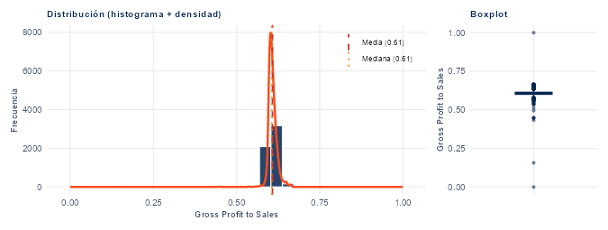

El histograma de Gross Profit to Sales muestra un marcado sesgo a la izquierda (asimetría negativa), con una media de 60.80% y una mediana de 60.61%. La curtosis observada de 377.59 indica una concentración notable de observaciones alrededor de la zona central, acompañada por la presencia de valores atípicos en las colas. Esta morfología sugiere una alta homogeneidad en el grueso de las empresas analizadas, pero con comportamientos extremos puntuales a monitorear en la etapa de preprocesamiento.

**Net Income to Stockholder’s Equity**

| Variable | N | Media | DS | Curtosis | Mediana | Mínimo | Máximo | Q1 | Q3 | IQR |
| --- | --- | --- | --- | --- | --- | --- | --- | --- | --- | --- |
| Net Income to Stockholder’s Equity | 5456 | 0.8403844 | 0.0157814 | 1735.709 | 0.8411946 | 0 | 1 | 0.8401274 | 0.842348 | 0.0022206 |

Net Income to Stockholder’s Equity

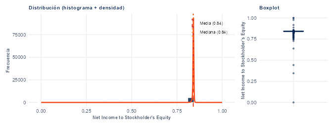

El histograma de Net Income to Stockholder’s Equity muestra un marcado sesgo a la izquierda (asimetría negativa), con una media de 84.04% y una mediana de 84.12%. La curtosis observada de 1737.30 indica una concentración notable de observaciones alrededor de la zona central, acompañada por la presencia de valores atípicos en las colas. Esta morfología sugiere una alta homogeneidad en el grueso de las empresas analizadas, pero con comportamientos extremos puntuales a monitorear en la etapa de preprocesamiento.

**Liability to Equity**

| Variable | N | Media | DS | Curtosis | Mediana | Mínimo | Máximo | Q1 | Q3 | IQR |
| --- | --- | --- | --- | --- | --- | --- | --- | --- | --- | --- |
| Liability to Equity | 5456 | 0.2803822 | 0.0149296 | 1256.56 | 0.2787654 | 0 | 1 | 0.2769511 | 0.2814694 | 0.0045183 |

Liability to Equity

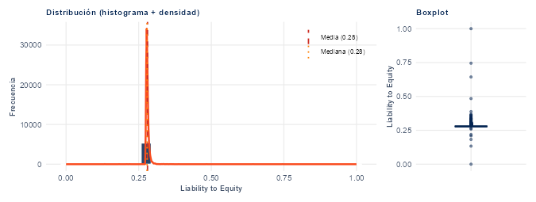

El histograma de Liability to Equity muestra un marcado sesgo a la derecha (asimetría positiva), con una media de 0.2804 ratio y una mediana de 0.2788 ratio. La curtosis observada de 1257.71 indica una concentración notable de observaciones alrededor de la zona central, acompañada por la presencia de valores atípicos en las colas. Esta morfología sugiere una alta homogeneidad en el grueso de las empresas analizadas, pero con comportamientos extremos puntuales a monitorear en la etapa de preprocesamiento.

**Degree of Financial Leverage (DFL)**

| Variable | N | Media | DS | Curtosis | Mediana | Mínimo | Máximo | Q1 | Q3 | IQR |
| --- | --- | --- | --- | --- | --- | --- | --- | --- | --- | --- |
| Degree of Financial Leverage (DFL) | 5456 | 0.027599 | 0.0173603 | 2049.793 | 0.0268082 | 0 | 1 | 0.0267912 | 0.026914 | 0.0001229 |

Degree of Financial Leverage (DFL)

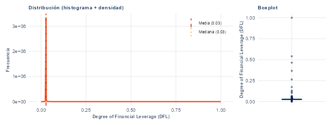

El histograma de Degree of Financial Leverage (DFL) muestra un marcado sesgo a la derecha (asimetría positiva), con una media de 0.0276 ratio y una mediana de 0.0268 ratio. La curtosis observada de 2051.67 indica una concentración notable de observaciones alrededor de la zona central, acompañada por la presencia de valores atípicos en las colas. Esta morfología sugiere una alta homogeneidad en el grueso de las empresas analizadas, pero con comportamientos extremos puntuales a monitorear en la etapa de preprocesamiento.

**Interest Coverage Ratio (Interest expense to EBIT)**

| Variable | N | Media | DS | Curtosis | Mediana | Mínimo | Máximo | Q1 | Q3 | IQR |
| --- | --- | --- | --- | --- | --- | --- | --- | --- | --- | --- |
| Interest Coverage Ratio (Interest expense to EBIT) | 5456 | 0.56535 | 0.0146681 | 749.4875 | 0.5652523 | 0 | 1 | 0.5651584 | 0.5657364 | 0.000578 |

Interest Coverage Ratio (Interest expense to EBIT)

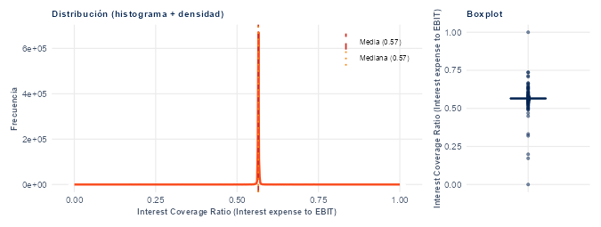

El histograma de Interest Coverage Ratio (Interest expense to EBIT) muestra un marcado sesgo a la izquierda (asimetría negativa), con una media de 0.5653 ratio y una mediana de 0.5653 ratio. La curtosis observada de 750.18 indica una concentración notable de observaciones alrededor de la zona central, acompañada por la presencia de valores atípicos en las colas. Esta morfología sugiere una alta homogeneidad en el grueso de las empresas analizadas, pero con comportamientos extremos puntuales a monitorear en la etapa de preprocesamiento.

**Equity to Liability**

| Variable | N | Media | DS | Curtosis | Mediana | Mínimo | Máximo | Q1 | Q3 | IQR |
| --- | --- | --- | --- | --- | --- | --- | --- | --- | --- | --- |
| Equity to Liability | 5456 | 0.047639 | 0.0520178 | 98.62983 | 0.0338789 | 0 | 1 | 0.0244381 | 0.052727 | 0.0282889 |

Equity to Liability

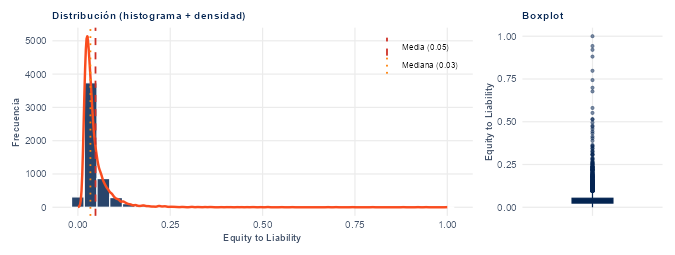

El histograma de Equity to Liability muestra un marcado sesgo a la derecha (asimetría positiva), con una media de 0.0476 ratio y una mediana de 0.0339 ratio. La curtosis observada de 98.72 indica una concentración notable de observaciones alrededor de la zona central, acompañada por la presencia de valores atípicos en las colas. Esta morfología sugiere una alta homogeneidad en el grueso de las empresas analizadas, pero con comportamientos extremos puntuales a monitorear en la etapa de preprocesamiento.

#### 2.3.2.3 Varianza cercana a cero

```r
varianzas  <- sapply(train_df[num_vars], var, na.rm = TRUE)
vars_bajas <- varianzas[varianzas < 1e-6]

cat(sprintf("Variables con varianza baja: %d\n", length(vars_bajas)))
```

```
## Variables con varianza baja: 1
```

```r
if (length(vars_bajas) > 0) {
  print(vars_bajas)
} else {
  cat("Ninguna variable numérica tiene varianza cercana a cero en train.\n")
}
```

```
## Total income/Total expense
##               2.229908e-07
```

### 2.3.3 Variables categóricas

#### 2.3.3.1 Tabla de frecuencias y gráficos

```r
unidad_indicador <- function(variable) {
  # Devuelve la unidad/concepto con el que debe presentarse cada indicador.
  # No convierte el valor: solo define cómo debe interpretarse en el texto.
  nombre <- str_to_lower(variable)
  contiene <- function(terms) any(vapply(terms, function(t) grepl(t, nombre, fixed = TRUE), logical(1)))

  if (contiene(c("day", "interval"))) return("días")
  if (contiene(c("per share", "eps", "net value per share"))) return("Yuan ¥/acción")
  if (contiene("per person")) return("Yuan ¥/persona")

  # En estas variables el valor del dataset se interpreta directamente
  # como una razón/ratio. No se expresa como "veces".
  if (contiene(c("turnover", "frequency"))) return("ratio")
  if (contiene(c(
    "current ratio", "quick ratio", "coverage ratio", "financial leverage",
    "borrowing dependency", "total debt/total net worth", "/equity", "to equity",
    "/net worth", "to net worth", "inventory and accounts receivable/net value",
    "cash/current liability", "quick assets/current liability",
    "inventory/current liability", "funds to liability", "liability to current assets",
    "equity to liability", "cash flow to liability", "total income/total expense"
  ))) return("ratio")
  if (contiene(c(
    "%", "roa", "rate", "growth", "margin", "to assets", "/assets", "assets/",
    "to sales", "paid-in capital", "net income to stockholder", "cash flow to equity",
    "interest expense ratio"
  ))) return("porcentaje")
  "ratio"
}

formatear_valor <- function(variable, valor, decimales = 4) {
  # Formatea un valor para las interpretaciones narrativas. Los indicadores
  # definidos como porcentaje se convierten de su escala decimal a porcentaje;
  # los ratios se mantienen en su escala original.
  if (is.na(valor)) return("NA")
  unidad <- unidad_indicador(variable)
  if (unidad == "porcentaje") return(sprintf("%.2f%%", valor * 100))
  paste(sprintf(paste0("%.", decimales, "f"), valor), unidad)
}

for (var in cat_vars) {
  cat(paste0('<details class="report-details"><summary>', var, '</summary><div class="report-body">'))
  # 1. Cálculo de Frecuencias Absolutas (N) y Relativas (%)
  conteo <- as.data.frame(table(Categoría = train_df[[var]]), stringsAsFactors = FALSE) %>%
    rename(N = Freq) %>%
    arrange(desc(N)) %>%
    mutate(`Porcentaje (%)` = N / nrow(train_df) * 100)

  tabla_estilo(conteo,
               formatos = list(N = fmt_int, `Porcentaje (%)` = "%.2f%%"),
               titulo = paste0("Tabla de Frecuencias: ", var))

  # 2. Generación del Gráfico de Barras
  colores_barras <- c(PALETTE$downriver, PALETTE$poinciana, PALETTE$flame, PALETTE$tangerine, PALETTE$tagao)
  conteo$pct <- conteo$N / nrow(train_df) * 100
  p <- ggplot(conteo, aes(x = Categoría, y = N, fill = Categoría)) +
    geom_col(color = "#FFFFFF", linewidth = 1.2) +
    geom_text(aes(label = sprintf("%s\n(%.2f%%)", fmt_int(N), pct)),
              vjust = -0.3, fontface = "bold", size = 3.4, color = PALETTE$downriver) +
    scale_fill_manual(values = colores_barras[seq_len(nrow(conteo))]) +
    ylim(0, max(conteo$N) * 1.18) +
    labs(title = paste0("Distribución de Frecuencias: ", var),
         x = "Categoría / Flag", y = "Número de Empresas (N)") +
    tema_eda + theme(axis.text.y = element_blank(), panel.grid = element_blank())
  fig_file <- tempfile(fileext = ".png")
  ggsave(fig_file, p, width = 8, height = 4.2, dpi = 100)
  cat(paste0('<div style="text-align:center;"><img src="data:…',
             base64enc::base64encode(fig_file), '" style="max-width:80%;height:auto;"></div>\n\n'))

  # 3. Interpretación Dinámica
  num_cats <- length(unique(conteo$Categoría))
  cat_dominante <- sprintf("%.1f", as.numeric(conteo$Categoría[1]))
  pct_dominante <- conteo$`Porcentaje (%)`[1]
  n_dominante   <- conteo$N[1]

  if (num_cats == 1) {
    detalles_interp <- paste0(
      "La variable <span style='color:", PALETTE$downriver, ";'>", var, "</span> presenta una varianza nula dentro del ",
      "conjunto de entrenamiento (<code>train_df</code>), constituida al 100% por la categoría ",
      "<span style='color:", PALETTE$downriver, ";'>", cat_dominante, "</span> (<i>N</i> = ", fmt_int(n_dominante), " empresas). ",
      "Al no contar con variabilidad entre las observaciones, esta variable no aporta poder discriminante ni ",
      "información predictiva para los modelos de Machine Learning, por lo que se sugiere su exclusión en el ",
      "preprocesamiento."
    )
  } else {
    cat_minoritaria <- sprintf("%.1f", as.numeric(conteo$Categoría[2]))
    pct_minoritaria <- conteo$`Porcentaje (%)`[2]
    n_minoritaria   <- conteo$N[2]
    detalles_interp <- paste0(
      "El análisis de la variable <span style='color:", PALETTE$downriver, ";'>", var, "</span> revela una marcada ",
      "asimetría en la distribución de sus categorías. La categoría dominante ",
      "<span style='color:", PALETTE$downriver, ";'>", cat_dominante, "</span> representa el ",
      "<span style='color:", PALETTE$downriver, ";'>", sprintf("%.2f", pct_dominante), "%</span> de la muestra (<i>N</i> = ",
      sprintf("%s.0", fmt_int(n_dominante)), "), ",
      "mientras que la categoría <span style='color:", PALETTE$poinciana, ";'>", cat_minoritaria, "</span> concentra ",
      "únicamente el <span style='color:", PALETTE$poinciana, ";'>", sprintf("%.2f", pct_minoritaria), "%</span> de los registros ",
      "(<i>N</i> = ", fmt_int(n_minoritaria), " empresas). Esta desproporción evidencia un comportamiento altamente desbalanceado ",
      "en este indicador financiero dentro de las empresas evaluadas."
    )
  }
  tarjeta_interpretacion(paste0("Interpretación de ", var), detalles_interp)
  cat("</div></details>\n")
}
```

**Liability-Assets Flag**

Tabla de Frecuencias: Liability-Assets Flag

| Categoría | N | Porcentaje (%) |
| --- | --- | --- |
| 0 | 5,449 | 99.87% |
| 1 | 7 | 0.13% |

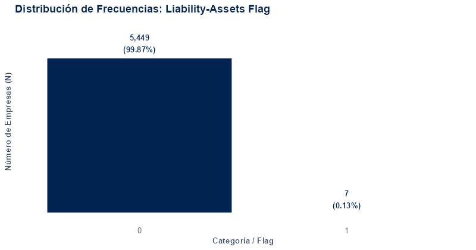

Interpretación de Liability-Assets Flag

El análisis de la variable Liability-Assets Flag revela una marcada asimetría en la distribución de sus categorías. La categoría dominante 0.0 representa el 99.87% de la muestra (*N* = 5,449.0), mientras que la categoría 1.0 concentra únicamente el 0.13% de los registros (*N* = 7 empresas). Esta desproporción evidencia un comportamiento altamente desbalanceado en este indicador financiero dentro de las empresas evaluadas.

**Net Income Flag**

Tabla de Frecuencias: Net Income Flag

| Categoría | N | Porcentaje (%) |
| --- | --- | --- |
| 1 | 5,456 | 100.00% |

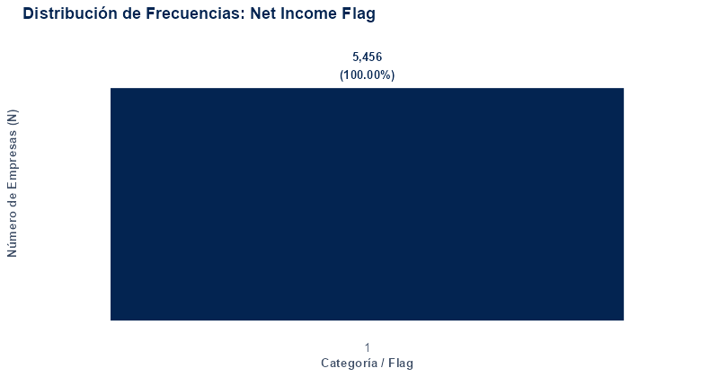

Interpretación de Net Income Flag

La variable Net Income Flag presenta una varianza nula dentro del conjunto de entrenamiento (`train_df`), constituida al 100% por la categoría 1.0 (*N* = 5,456 empresas). Al no contar con variabilidad entre las observaciones, esta variable no aporta poder discriminante ni información predictiva para los modelos de Machine Learning, por lo que se sugiere su exclusión en el preprocesamiento.

### 2.3.4 Análisis de outliers y sesgos

Antes de pasar al análisis bivariado, es importante identificar qué variables tienen distribuciones muy sesgadas y/o outliers extremos, ya que esto afecta tanto la interpretación visual como la elección de modelos y transformaciones en la fase de Machine Learning.

#### 2.3.4.1 TOP 10 variables con mayor sesgo, en valor absoluto

```r
# 1. Cálculo de Asimetría (Skewness)
skew_vals <- sapply(train_df[num_vars], function(x) e1071::skewness(x, na.rm = TRUE, type = 2))
skew_vals <- skew_vals[order(abs(skew_vals), decreasing = TRUE)]
top_skew_vars <- names(skew_vals)[1:6]

# 2. Tabla Ejecutiva del Top 10 con mayor asimetría absoluta
df_skew_top10 <- tibble(
  Variable = names(skew_vals)[1:10],
  `Coeficiente de Asimetría (Skewness)` = as.numeric(skew_vals[1:10])
)

clasificar_sesgo <- function(val) {
  case_when(
    val >= 1.0  ~ "Sesgo Positivo Severo (Derecha)",
    val <= -1.0 ~ "Sesgo Negativo Severo (Izquierda)",
    abs(val) >= 0.5 ~ "Sesgo Moderado",
    TRUE ~ "Relativamente Simétrica"
  )
}
df_skew_top10[["Diagnóstico de Morfología"]] <- clasificar_sesgo(df_skew_top10[["Coeficiente de Asimetría (Skewness)"]])

tabla_estilo(
  df_skew_top10,
  formatos = list(`Coeficiente de Asimetría (Skewness)` = "%+.4f"),
  titulo = "Top 10 Variables Numéricas con Mayor Asimetría (Skewness)"
)
```

Top 10 Variables Numéricas con Mayor Asimetría (Skewness)

| Variable | Coeficiente de Asimetría (Skewness) | Diagnóstico de Morfología |
| --- | --- | --- |
| Current Ratio | +73.8647 | Sesgo Positivo Severo (Derecha) |
| Fixed Assets to Assets | +73.8647 | Sesgo Positivo Severo (Derecha) |
| Net Value Growth Rate | +71.8203 | Sesgo Positivo Severo (Derecha) |
| Contingent liabilities/Net worth | +71.4694 | Sesgo Positivo Severo (Derecha) |
| Realized Sales Gross Profit Growth Rate | +69.8705 | Sesgo Positivo Severo (Derecha) |
| Operating Profit Rate | -69.7810 | Sesgo Negativo Severo (Izquierda) |
| Operating Profit Growth Rate | -67.5920 | Sesgo Negativo Severo (Izquierda) |
| Cash Flow to Sales | -65.5068 | Sesgo Negativo Severo (Izquierda) |
| Working capitcal Turnover Rate | -64.6711 | Sesgo Negativo Severo (Izquierda) |
| After-tax net Interest Rate | -61.9682 | Sesgo Negativo Severo (Izquierda) |

Las variables presentan valores de sesgo muy altos, tanto positivos como negativos. Esto indica que varias distribuciones están alejadas de una distribución simétrica y pueden presentar valores extremos.

Conclusión: Varias variables presentan un sesgo elevado, lo que sugiere la presencia de distribuciones muy asimétricas y posibles valores extremos. Estas variables deberán revisarse durante el preprocesamiento para determinar si requieren alguna transformación, especialmente si se utilizan modelos sensibles a la escala o a la distribución de los datos.

#### 2.3.4.2 Boxplots de las variables más sesgadas

```r
# Boxplots de las 6 variables con mayor sesgo absoluto
plot_box_skew <- function(var) {
  ggplot(train_df, aes(x = "", y = .data[[var]])) +
    geom_boxplot(fill = PALETTE$downriver, color = PALETTE$downriver, width = 0.35,
outlier.color = PALETTE$poinciana,
                 outlier.alpha = 0.55, outlier.size = 1.6) +
    labs(title = sprintf("%s\n(skew = %+.1f)", str_wrap(var, 26), skew_vals[[var]]),
         x = NULL, y = NULL) +
    tema_eda +
    theme(plot.title = element_text(size = 10.5, face = "bold", color = PALETTE$downriver),
          axis.text.x = element_blank(), panel.grid.major.x = element_blank())
}

wrap_plots(lapply(top_skew_vars, plot_box_skew), ncol = 3) +
  plot_annotation(
    title = "Diagramas de Caja (Boxplots) para Variables con Mayor Sesgo (Train)",
    theme = theme(plot.title = element_text(face = "bold", size = 14, color = PALETTE$downriver))
  )
```

[figure not shown]

Los boxplots muestran que las variables con mayor sesgo presentan valores atípicos muy alejados de la mayoría de las observaciones. En varias de ellas, estos valores extremos explican gran parte del sesgo observado. Por ahora no se deberían eliminar automáticamente, ya que primero es necesario determinar si representan errores o situaciones reales de las empresas.

#### 2.3.4.3 TOP 15 variables con más outliers (regla IQR)

```r
# 1. Función para calcular el porcentaje de outliers mediante IQR
pct_outliers_iqr <- function(serie) {
  serie <- serie[!is.na(serie)]
  q <- quantile(serie, c(0.25, 0.75), names = FALSE)
  iqr <- q[2] - q[1]
  lower <- q[1] - 1.5 * iqr
  upper <- q[2] + 1.5 * iqr
  mean(serie < lower | serie > upper) * 100
}

outlier_pct <- sort(sapply(train_df[num_vars], pct_outliers_iqr), decreasing = TRUE)
top15 <- outlier_pct[1:15]

df_top15_tabla <- tibble(Variable = names(top15), `% Outliers (IQR)` = as.numeric(top15))

tabla_estilo(
  df_top15_tabla,
  formatos = list(`% Outliers (IQR)` = "%.2f%%"),
  titulo = "Top 15 Variables con Mayor Proporción de Valores Atípicos"
)
```

Top 15 Variables con Mayor Proporción de Valores Atípicos

| Variable | % Outliers (IQR) |
| --- | --- |
| Degree of Financial Leverage (DFL) | 22.23% |
| Fixed Assets Turnover Frequency | 20.82% |
| Interest Coverage Ratio (Interest expense to EBIT) | 20.66% |
| Current Asset Turnover Rate | 20.64% |
| Total Asset Growth Rate | 20.05% |
| Interest Expense Ratio | 19.21% |
| Cash Flow to Liability | 18.09% |
| No-credit Interval | 16.44% |
| Non-industry income and expenditure/revenue | 16.11% |
| Cash Flow to Sales | 15.54% |
| Operating Profit Growth Rate | 15.29% |
| Continuous Net Profit Growth Rate | 15.27% |
| After-tax Net Profit Growth Rate | 15.16% |
| Regular Net Profit Growth Rate | 15.16% |
| Inventory/Working Capital | 13.95% |

```r
# 2. Gráfico horizontal
df_top15_plot <- df_top15_tabla %>%
  mutate(etiqueta = factor(str_trunc(Variable, 38), levels = rev(str_trunc(Variable, 38))))

ggplot(df_top15_plot, aes(x = etiqueta, y = `% Outliers (IQR)`)) +
  geom_col(fill = PALETTE$downriver, color = "#FFFFFF", linewidth = 0.8) +
  geom_text(aes(label = sprintf("%.1f%%", `% Outliers (IQR)`)), hjust = -0.15, size = 3.3,
            fontface = "bold", color = PALETTE$downriver) +
  coord_flip(clip = "off") +
  expand_limits(y = max(df_top15_plot$`% Outliers (IQR)`) * 1.15) +
  labs(title = "Top 15 Variables con Más Outliers (Criterio IQR, Train)",
       x = NULL, y = "% de empresas marcadas como outlier (Criterio 1.5 × IQR)") +
  tema_eda +
  theme(panel.grid.major.y = element_blank(), axis.text.y = element_text(color = PALETTE$downriver))
```

[figure not shown]

En general, varias variables presentan una proporción considerable de valores atípicos. Sin embargo, esto no significa que deban eliminarse automáticamente, ya que pueden representar situaciones financieras reales de algunas empresas. Estos resultados deberán considerarse posteriormente al definir el preprocesamiento de los datos.

## 2.4 Análisis bivariado

### 2.4.1 variables numéricas vs objetivo

#### 2.4.1.1 Estadísticas descriptivas

```r
# 1. TABLA CONSOLIDADA: las 93 variables en una sola tabla. Se ordena por
# correlación de Spearman absoluta con el target, para que las variables más
# relevantes aparezcan primero (ver justificación de Spearman al inicio de la sección 6).
corr_spearman_objetivo <- sapply(num_vars, function(v) {
  suppressWarnings(cor(train_df[[v]], train_df[[TARGET]], method = "spearman"))
})

filas_biv <- map_dfr(num_vars, function(var) {
  grupo_0 <- train_df[[var]][train_df[[TARGET]] == 0]; grupo_0 <- grupo_0[!is.na(grupo_0)]
  grupo_1 <- train_df[[var]][train_df[[TARGET]] == 1]; grupo_1 <- grupo_1[!is.na(grupo_1)]
  tibble(
    Variable = var,
    `Correlación Spearman (r)` = corr_spearman_objetivo[[var]],
    `Media (No quiebra)`   = mean(grupo_0),
    `Media (Quiebra)`      = mean(grupo_1),
    `Mediana (No quiebra)` = median(grupo_0),
    `Mediana (Quiebra)`    = median(grupo_1)
  )
})
df_bivariado_todas <- filas_biv %>% arrange(desc(abs(`Correlación Spearman (r)`)))

tabla_estilo_scroll(df_bivariado_todas, formatos = list(
  `Correlación Spearman (r)` = "%+.3f",
  `Media (No quiebra)` = "%.4f", `Media (Quiebra)` = "%.4f",
  `Mediana (No quiebra)` = "%.4f", `Mediana (Quiebra)` = "%.4f"
), titulo = "Comparación Bivariada de las 93 Variables numéricas vs. Bankrupt? (ordenadas por relevancia)",
alto_px = 420)
```

Comparación Bivariada de las 93 Variables numéricas vs. Bankrupt? (ordenadas por relevancia)

| Variable | Correlación Spearman (r) | Media (No quiebra) | Media (Quiebra) | Mediana (No quiebra) | Mediana (Quiebra) |
| --- | --- | --- | --- | --- | --- |
| Persistent EPS in the Last Four Seasons | -0.244 | 0.2301 | 0.1893 | 0.2253 | 0.1969 |
| Net Income to Total Assets | -0.240 | 0.8101 | 0.7402 | 0.8116 | 0.7645 |
| Net profit before tax/Paid-in capital | -0.238 | 0.1837 | 0.1479 | 0.1791 | 0.1551 |
| Per Share Net profit before tax (Yuan ¥) | -0.238 | 0.1855 | 0.1481 | 0.1804 | 0.1555 |
| Retained Earnings to Total Assets | -0.236 | 0.9356 | 0.9056 | 0.9381 | 0.9123 |
| Continuous interest rate (after tax) | -0.234 | 0.7815 | 0.7808 | 0.7816 | 0.7813 |
| Total debt/Total net worth | +0.230 | 5056936.8072 | 18556149.7683 | 0.0054 | 0.0157 |
| Total income/Total expense | -0.230 | 0.0024 | 0.0021 | 0.0023 | 0.0020 |
| ROA(B) before interest and depreciation after tax | -0.230 | 0.5569 | 0.4631 | 0.5544 | 0.4885 |
| ROA(C) before interest and depreciation before interest | -0.228 | 0.5083 | 0.4191 | 0.5049 | 0.4431 |
| Debt ratio % | +0.228 | 0.1108 | 0.1889 | 0.1092 | 0.1874 |
| Net worth/Assets | -0.228 | 0.8892 | 0.8111 | 0.8908 | 0.8126 |
| Equity to Liability | -0.228 | 0.0485 | 0.0244 | 0.0345 | 0.0187 |
| ROA(A) before interest and % after tax | -0.228 | 0.5621 | 0.4586 | 0.5618 | 0.4901 |
| Borrowing dependency | +0.228 | 0.3740 | 0.3923 | 0.3725 | 0.3827 |
| After-tax net Interest Rate | -0.226 | 0.8092 | 0.8084 | 0.8094 | 0.8091 |
| Net Income to Stockholder’s Equity | -0.224 | 0.8409 | 0.8245 | 0.8412 | 0.8367 |
| Pre-tax net Interest Rate | -0.224 | 0.7973 | 0.7965 | 0.7975 | 0.7971 |
| Net Value Per Share (B) | -0.215 | 0.1913 | 0.1601 | 0.1849 | 0.1579 |
| Net Value Per Share (A) | -0.215 | 0.1913 | 0.1600 | 0.1850 | 0.1579 |
| Net Value Per Share (C) | -0.214 | 0.1913 | 0.1602 | 0.1850 | 0.1579 |
| Quick Ratio | -0.212 | 8094515.0996 | 49358288.7740 | 0.0076 | 0.0027 |
| Liability to Equity | +0.211 | 0.2799 | 0.2953 | 0.2787 | 0.2858 |
| Non-industry income and expenditure/revenue | -0.208 | 0.3035 | 0.3025 | 0.3035 | 0.3033 |
| Net Value Growth Rate | -0.208 | 256215.6014 | 49893048.1287 | 0.0005 | 0.0004 |
| Current Ratio | -0.201 | 521920.6836 | 0.0068 | 0.0107 | 0.0059 |
| Current Liability to Current Assets | +0.201 | 0.0304 | 0.0634 | 0.0272 | 0.0488 |
| Operating Profit Per Share (Yuan ¥) | -0.199 | 0.1097 | 0.0870 | 0.1048 | 0.0903 |
| Operating profit/Paid-in capital | -0.199 | 0.1096 | 0.0871 | 0.1046 | 0.0904 |
| Quick Assets/Current Liability | -0.199 | 4649838.6911 | 0.0047 | 0.0081 | 0.0034 |

[output cut: 63 more lines]

```r
# 2. DEEP DIVE: tabla + interpretación completa para TODAS las variables numéricas.
# Cada variable es un bloque <details> plegable; todos se muestran juntos dentro
# de un único contenedor con scroll interno.
cat(sprintf("<div style='color:%s;font-family:Segoe UI, sans-serif;margin-top:20px;font-weight:700;font-size:16px;'>Análisis bivariado detallado de todas las variables numéricas</div>\n\n",
            PALETTE$downriver))
```

Análisis bivariado detallado de todas las variables numéricas

````r
detalles_deep_dive <- character(length(num_vars))
for (k in seq_along(num_vars)) {
  var <- num_vars[k]
  stats_list <- map_dfr(c(0, 1), function(val) {
    grupo <- train_df[[var]][train_df[[TARGET]] == val]; grupo <- grupo[!is.na(grupo)]
    q <- quantile(grupo, c(0.25, 0.75), names = FALSE)
    tibble(
      `Estado Financiero` = sprintf("Clase %d (%s)", val, ifelse(val == 0, "Solvente", "Quiebra")),
      N = length(grupo), Media = mean(grupo), DS = sd(grupo), Mediana = median(grupo),
      `Mínimo` = min(grupo), `Máximo` = max(grupo), Q1 = q[1], Q3 = q[2], IQR = q[2] - q[1]
    )
  })
  f4 <- "%.4f"
  tabla_h <- gsub("\n", " ", tabla_html(stats_list, formatos = list(
    N = fmt_int, Media = f4, DS = f4, Mediana = f4, `Mínimo` = f4, `Máximo` = f4, Q1 = f4, Q3 = f4, IQR = f4
  )))

  m_0 <- stats_list$Media[1];   m_1 <- stats_list$Media[2]
  med_0 <- stats_list$Mediana[1]; med_1 <- stats_list$Mediana[2]
  diff_media <- m_1 - m_0
  resumen_vals <- paste0("(Media = ", formatear_valor(var, m_1), ", Mediana = ", formatear_valor(var, med_1),
                         ") frente a empresas solventes (Media = ", formatear_valor(var, m_0),
                         ", Mediana = ", formatear_valor(var, med_0), ").")
  if (is.na(diff_media) || abs(diff_media) < 1e-4) {
    tendencia <- "no presenta diferencias sustanciales entre ambos grupos, sugiriendo un poder discriminante limitado de forma univariada."
    color_borde <- PALETTE$stone_blue
  } else if (diff_media < 0) {
    tendencia <- paste0("muestra una tendencia a registrar <span style='color:", PALETTE$poinciana,
                        ";'>valores inferiores en empresas en quiebra</span> ", resumen_vals)
    color_borde <- PALETTE$poinciana
  } else {
    tendencia <- paste0("muestra una tendencia a registrar <span style='color:", PALETTE$flame,
                        ";'>valores superiores en empresas en quiebra</span> ", resumen_vals)
    color_borde <- PALETTE$flame
  }

  interpretacion_html <- paste0(
    "Al segmentar la variable <span style='color:", PALETTE$downriver, ";'>", var, "</span> según la condición de ",
    "insolvencia (<code>", TARGET, "</code>), se observa que la distribución ", tendencia,
    " Esta diferencia entre los centros de tendencia central es un indicador clave para anticipar la importancia de esta variable ",
    "dentro de los modelos de clasificación."
  )

  detalles_deep_dive[k] <- paste0(
    '<details class="deep-dive-details"><summary>', var, '</summary><div style="padding:16px 18px;">',
    '<div style="margin-bottom:14px;overflow-x:auto;">', tabla_h, '</div>',
    '<div style="background-color:', PALETTE$bg_card, ';border-left:5px solid ', color_borde,
    ';border-radius:6px;padding:14px 18px;font-family:\'Segoe UI\',-apple-system,BlinkMacSystemFont,Roboto,sans-serif;">',
    '<div style="color:', PALETTE$downriver, ';margin:0 0 8px 0;font-size:13px;font-weight:700;letter-spacing:.5px;">Interpretación Bivariada</div>',
    '<p style="margin:0;color:', PALETTE$stone_blue, ';font-size:13.5px;line-height:1.6;">', interpretacion_html, '</p>',
    '</div></div></details>'
  )
}

html_estilo_deep_dive <- paste0(
  "<style>.deep-dive-details{margin:0 0 10px 0;border:1px solid #E1E4E9;border-radius:8px;overflow:hidden;background-color:#FFFFFF;}",
  ".deep-dive-details summary{padding:12px 18px;cursor:pointer;font-size:14.5px;font-weight:600;color:", PALETTE$downriver,
  ";background-color:", PALETTE$bg_card, ";list-style:none;}",
  ".deep-dive-details summary::-webkit-details-marker{display:none;}",
  ".deep-dive-details summary::before{content:'\u25B6 ';font-size:11px;color:", PALETTE$stone_blue, ";}",
  ".deep-dive-details[open] summary::before{content:'\u25BC ';}</style>"
)

# 3. Contenedor único con scroll interno para las 93 variables plegables
# Bloque HTML crudo (```{=html}): Pandoc lo deja pasar sin reinterpretarlo
cat("\n\n```{=html}\n", html_estilo_deep_dive,
    "<div style='max-height:640px;overflow-y:auto;border:1px solid #E1E4E9;border-radius:8px;padding:14px;background-color:#FAFBFC;'>",
    paste(detalles_deep_dive, collapse = ""), "</div>\n```\n\n", sep = "")
````

**ROA(C) before interest and depreciation before interest**

| Estado Financiero | N | Media | DS | Mediana | Mínimo | Máximo | Q1 | Q3 | IQR |
| --- | --- | --- | --- | --- | --- | --- | --- | --- | --- |
| Clase 0 (Solvente) | 5,269 | 0.5083 | 0.0575 | 0.5049 | 0.0000 | 0.9715 | 0.4790 | 0.5371 | 0.0581 |
| Clase 1 (Quiebra) | 187 | 0.4191 | 0.0830 | 0.4431 | 0.0243 | 0.5770 | 0.3926 | 0.4703 | 0.0777 |

Interpretación Bivariada

Al segmentar la variable ROA(C) before interest and depreciation before interest según la condición de insolvencia (`Bankrupt?`), se observa que la distribución muestra una tendencia a registrar valores inferiores en empresas en quiebra (Media = 41.91%, Mediana = 44.31%) frente a empresas solventes (Media = 50.83%, Mediana = 50.49%). Esta diferencia entre los centros de tendencia central es un indicador clave para anticipar la importancia de esta variable dentro de los modelos de clasificación.

**ROA(A) before interest and % after tax**

| Estado Financiero | N | Media | DS | Mediana | Mínimo | Máximo | Q1 | Q3 | IQR |
| --- | --- | --- | --- | --- | --- | --- | --- | --- | --- |
| Clase 0 (Solvente) | 5,269 | 0.5621 | 0.0604 | 0.5618 | 0.0069 | 1.0000 | 0.5379 | 0.5902 | 0.0522 |
| Clase 1 (Quiebra) | 187 | 0.4586 | 0.1063 | 0.4901 | 0.0000 | 0.5829 | 0.4313 | 0.5292 | 0.0979 |

Interpretación Bivariada

Al segmentar la variable ROA(A) before interest and % after tax según la condición de insolvencia (`Bankrupt?`), se observa que la distribución muestra una tendencia a registrar valores inferiores en empresas en quiebra (Media = 45.86%, Mediana = 49.01%) frente a empresas solventes (Media = 56.21%, Mediana = 56.18%). Esta diferencia entre los centros de tendencia central es un indicador clave para anticipar la importancia de esta variable dentro de los modelos de clasificación.

**ROA(B) before interest and depreciation after tax**

| Estado Financiero | N | Media | DS | Mediana | Mínimo | Máximo | Q1 | Q3 | IQR |
| --- | --- | --- | --- | --- | --- | --- | --- | --- | --- |
| Clase 0 (Solvente) | 5,269 | 0.5569 | 0.0578 | 0.5544 | 0.0000 | 1.0000 | 0.5301 | 0.5860 | 0.0558 |
| Clase 1 (Quiebra) | 187 | 0.4631 | 0.0916 | 0.4885 | 0.0335 | 0.6191 | 0.4343 | 0.5197 | 0.0854 |

Interpretación Bivariada

Al segmentar la variable ROA(B) before interest and depreciation after tax según la condición de insolvencia (`Bankrupt?`), se observa que la distribución muestra una tendencia a registrar valores inferiores en empresas en quiebra (Media = 46.31%, Mediana = 48.85%) frente a empresas solventes (Media = 55.69%, Mediana = 55.44%). Esta diferencia entre los centros de tendencia central es un indicador clave para anticipar la importancia de esta variable dentro de los modelos de clasificación.

**Operating Gross Margin**

| Estado Financiero | N | Media | DS | Mediana | Mínimo | Máximo | Q1 | Q3 | IQR |
| --- | --- | --- | --- | --- | --- | --- | --- | --- | --- |
| Clase 0 (Solvente) | 5,269 | 0.6084 | 0.0177 | 0.6063 | 0.0000 | 1.0000 | 0.6007 | 0.6143 | 0.0136 |
| Clase 1 (Quiebra) | 187 | 0.5985 | 0.0153 | 0.5986 | 0.5329 | 0.6652 | 0.5938 | 0.6034 | 0.0097 |

Interpretación Bivariada

Al segmentar la variable Operating Gross Margin según la condición de insolvencia (`Bankrupt?`), se observa que la distribución muestra una tendencia a registrar valores inferiores en empresas en quiebra (Media = 59.85%, Mediana = 59.86%) frente a empresas solventes (Media = 60.84%, Mediana = 60.63%). Esta diferencia entre los centros de tendencia central es un indicador clave para anticipar la importancia de esta variable dentro de los modelos de clasificación.

**Realized Sales Gross Margin**

| Estado Financiero | N | Media | DS | Mediana | Mínimo | Máximo | Q1 | Q3 | IQR |
| --- | --- | --- | --- | --- | --- | --- | --- | --- | --- |
| Clase 0 (Solvente) | 5,269 | 0.6083 | 0.0177 | 0.6063 | 0.0000 | 1.0000 | 0.6006 | 0.6142 | 0.0136 |
| Clase 1 (Quiebra) | 187 | 0.5985 | 0.0152 | 0.5988 | 0.5329 | 0.6652 | 0.5938 | 0.6034 | 0.0097 |

Interpretación Bivariada

Al segmentar la variable Realized Sales Gross Margin según la condición de insolvencia (`Bankrupt?`), se observa que la distribución muestra una tendencia a registrar valores inferiores en empresas en quiebra (Media = 59.85%, Mediana = 59.88%) frente a empresas solventes (Media = 60.83%, Mediana = 60.63%). Esta diferencia entre los centros de tendencia central es un indicador clave para anticipar la importancia de esta variable dentro de los modelos de clasificación.

**Operating Profit Rate**

| Estado Financiero | N | Media | DS | Mediana | Mínimo | Máximo | Q1 | Q3 | IQR |
| --- | --- | --- | --- | --- | --- | --- | --- | --- | --- |
| Clase 0 (Solvente) | 5,269 | 0.9989 | 0.0054 | 0.9990 | 0.6121 | 0.9998 | 0.9990 | 0.9991 | 0.0001 |
| Clase 1 (Quiebra) | 187 | 0.9987 | 0.0007 | 0.9989 | 0.9919 | 0.9993 | 0.9988 | 0.9990 | 0.0002 |

Interpretación Bivariada

Al segmentar la variable Operating Profit Rate según la condición de insolvencia (`Bankrupt?`), se observa que la distribución muestra una tendencia a registrar valores inferiores en empresas en quiebra (Media = 99.87%, Mediana = 99.89%) frente a empresas solventes (Media = 99.89%, Mediana = 99.90%). Esta diferencia entre los centros de tendencia central es un indicador clave para anticipar la importancia de esta variable dentro de los modelos de clasificación.

**Pre-tax net Interest Rate**

| Estado Financiero | N | Media | DS | Mediana | Mínimo | Máximo | Q1 | Q3 | IQR |
| --- | --- | --- | --- | --- | --- | --- | --- | --- | --- |
| Clase 0 (Solvente) | 5,269 | 0.7973 | 0.0096 | 0.7975 | 0.1605 | 1.0000 | 0.7974 | 0.7976 | 0.0002 |
| Clase 1 (Quiebra) | 187 | 0.7965 | 0.0034 | 0.7971 | 0.7572 | 0.7978 | 0.7968 | 0.7974 | 0.0005 |

Interpretación Bivariada

Al segmentar la variable Pre-tax net Interest Rate según la condición de insolvencia (`Bankrupt?`), se observa que la distribución muestra una tendencia a registrar valores inferiores en empresas en quiebra (Media = 79.65%, Mediana = 79.71%) frente a empresas solventes (Media = 79.73%, Mediana = 79.75%). Esta diferencia entre los centros de tendencia central es un indicador clave para anticipar la importancia de esta variable dentro de los modelos de clasificación.

**After-tax net Interest Rate**

| Estado Financiero | N | Media | DS | Mediana | Mínimo | Máximo | Q1 | Q3 | IQR |
| --- | --- | --- | --- | --- | --- | --- | --- | --- | --- |
| Clase 0 (Solvente) | 5,269 | 0.8092 | 0.0118 | 0.8094 | 0.0000 | 1.0000 | 0.8093 | 0.8095 | 0.0002 |
| Clase 1 (Quiebra) | 187 | 0.8084 | 0.0045 | 0.8091 | 0.7616 | 0.8097 | 0.8088 | 0.8093 | 0.0005 |

Interpretación Bivariada

Al segmentar la variable After-tax net Interest Rate según la condición de insolvencia (`Bankrupt?`), se observa que la distribución muestra una tendencia a registrar valores inferiores en empresas en quiebra (Media = 80.84%, Mediana = 80.91%) frente a empresas solventes (Media = 80.92%, Mediana = 80.94%). Esta diferencia entre los centros de tendencia central es un indicador clave para anticipar la importancia de esta variable dentro de los modelos de clasificación.

**Non-industry income and expenditure/revenue**

| Estado Financiero | N | Media | DS | Mediana | Mínimo | Máximo | Q1 | Q3 | IQR |
| --- | --- | --- | --- | --- | --- | --- | --- | --- | --- |
| Clase 0 (Solvente) | 5,269 | 0.3035 | 0.0082 | 0.3035 | 0.0000 | 0.7303 | 0.3035 | 0.3036 | 0.0001 |
| Clase 1 (Quiebra) | 187 | 0.3025 | 0.0055 | 0.3033 | 0.2351 | 0.3054 | 0.3030 | 0.3034 | 0.0005 |

Interpretación Bivariada

Al segmentar la variable Non-industry income and expenditure/revenue según la condición de insolvencia (`Bankrupt?`), se observa que la distribución muestra una tendencia a registrar valores inferiores en empresas en quiebra (Media = 0.3025 ratio, Mediana = 0.3033 ratio) frente a empresas solventes (Media = 0.3035 ratio, Mediana = 0.3035 ratio). Esta diferencia entre los centros de tendencia central es un indicador clave para anticipar la importancia de esta variable dentro de los modelos de clasificación.

**Continuous interest rate (after tax)**

| Estado Financiero | N | Media | DS | Mediana | Mínimo | Máximo | Q1 | Q3 | IQR |
| --- | --- | --- | --- | --- | --- | --- | --- | --- | --- |
| Clase 0 (Solvente) | 5,269 | 0.7815 | 0.0096 | 0.7816 | 0.1335 | 1.0000 | 0.7816 | 0.7817 | 0.0002 |
| Clase 1 (Quiebra) | 187 | 0.7808 | 0.0034 | 0.7813 | 0.7427 | 0.7818 | 0.7810 | 0.7815 | 0.0005 |

Interpretación Bivariada

Al segmentar la variable Continuous interest rate (after tax) según la condición de insolvencia (`Bankrupt?`), se observa que la distribución muestra una tendencia a registrar valores inferiores en empresas en quiebra (Media = 78.08%, Mediana = 78.13%) frente a empresas solventes (Media = 78.15%, Mediana = 78.16%). Esta diferencia entre los centros de tendencia central es un indicador clave para anticipar la importancia de esta variable dentro de los modelos de clasificación.

**Operating Expense Rate**

| Estado Financiero | N | Media | DS | Mediana | Mínimo | Máximo | Q1 | Q3 | IQR |
| --- | --- | --- | --- | --- | --- | --- | --- | --- | --- |
| Clase 0 (Solvente) | 5,269 | 2017365998.8616 | 3252497551.0096 | 0.0003 | 0.0001 | 9990000000.0000 | 0.0002 | 4150000000.0000 | 4149999999.9998 |
| Clase 1 (Quiebra) | 187 | 1892625668.4495 | 3244721335.8459 | 0.0003 | 0.0001 | 9890000000.0000 | 0.0002 | 2995000000.0000 | 2994999999.9998 |

Interpretación Bivariada

Al segmentar la variable Operating Expense Rate según la condición de insolvencia (`Bankrupt?`), se observa que la distribución muestra una tendencia a registrar valores inferiores en empresas en quiebra (Media = 189262566844.95%, Mediana = 0.03%) frente a empresas solventes (Media = 201736599886.16%, Mediana = 0.03%). Esta diferencia entre los centros de tendencia central es un indicador clave para anticipar la importancia de esta variable dentro de los modelos de clasificación.

**Research and development expense rate**

| Estado Financiero | N | Media | DS | Mediana | Mínimo | Máximo | Q1 | Q3 | IQR |
| --- | --- | --- | --- | --- | --- | --- | --- | --- | --- |
| Clase 0 (Solvente) | 5,269 | 1991220212.5641 | 2633480352.8158 | 560000000.0000 | 0.0000 | 9980000000.0000 | 0.0001 | 3500000000.0000 | 3499999999.9999 |
| Clase 1 (Quiebra) | 187 | 1577572727.2728 | 2445983143.7744 | 153000000.0000 | 0.0000 | 9920000000.0000 | 0.0000 | 2240000000.0000 | 2240000000.0000 |

Interpretación Bivariada

Al segmentar la variable Research and development expense rate según la condición de insolvencia (`Bankrupt?`), se observa que la distribución muestra una tendencia a registrar valores inferiores en empresas en quiebra (Media = 157757272727.28%, Mediana = 15300000000.00%) frente a empresas solventes (Media = 199122021256.41%, Mediana = 56000000000.00%). Esta diferencia entre los centros de tendencia central es un indicador clave para anticipar la importancia de esta variable dentro de los modelos de clasificación.

**Cash flow rate**

| Estado Financiero | N | Media | DS | Mediana | Mínimo | Máximo | Q1 | Q3 | IQR |
| --- | --- | --- | --- | --- | --- | --- | --- | --- | --- |
| Clase 0 (Solvente) | 5,269 | 0.4677 | 0.0181 | 0.4653 | 0.0000 | 1.0000 | 0.4617 | 0.4712 | 0.0096 |
| Clase 1 (Quiebra) | 187 | 0.4611 | 0.0083 | 0.4613 | 0.4343 | 0.5431 | 0.4588 | 0.4631 | 0.0043 |

Interpretación Bivariada

Al segmentar la variable Cash flow rate según la condición de insolvencia (`Bankrupt?`), se observa que la distribución muestra una tendencia a registrar valores inferiores en empresas en quiebra (Media = 46.11%, Mediana = 46.13%) frente a empresas solventes (Media = 46.77%, Mediana = 46.53%). Esta diferencia entre los centros de tendencia central es un indicador clave para anticipar la importancia de esta variable dentro de los modelos de clasificación.

**Interest-bearing debt interest rate**

| Estado Financiero | N | Media | DS | Mediana | Mínimo | Máximo | Q1 | Q3 | IQR |
| --- | --- | --- | --- | --- | --- | --- | --- | --- | --- |
| Clase 0 (Solvente) | 5,269 | 17898083.1287 | 113408470.0047 | 0.0003 | 0.0000 | 990000000.0000 | 0.0002 | 0.0005 | 0.0003 |
| Clase 1 (Quiebra) | 187 | 3262032.0861 | 34023249.5167 | 0.0005 | 0.0000 | 430000000.0000 | 0.0004 | 0.0007 | 0.0003 |

Interpretación Bivariada

Al segmentar la variable Interest-bearing debt interest rate según la condición de insolvencia (`Bankrupt?`), se observa que la distribución muestra una tendencia a registrar valores inferiores en empresas en quiebra (Media = 326203208.61%, Mediana = 0.05%) frente a empresas solventes (Media = 1789808312.87%, Mediana = 0.03%). Esta diferencia entre los centros de tendencia central es un indicador clave para anticipar la importancia de esta variable dentro de los modelos de clasificación.

**Tax rate (A)**

| Estado Financiero | N | Media | DS | Mediana | Mínimo | Máximo | Q1 | Q3 | IQR |
| --- | --- | --- | --- | --- | --- | --- | --- | --- | --- |
| Clase 0 (Solvente) | 5,269 | 0.1178 | 0.1369 | 0.0832 | 0.0000 | 1.0000 | 0.0000 | 0.2097 | 0.2097 |
| Clase 1 (Quiebra) | 187 | 0.0354 | 0.1201 | 0.0000 | 0.0000 | 0.9755 | 0.0000 | 0.0000 | 0.0000 |

Interpretación Bivariada

Al segmentar la variable Tax rate (A) según la condición de insolvencia (`Bankrupt?`), se observa que la distribución muestra una tendencia a registrar valores inferiores en empresas en quiebra (Media = 3.54%, Mediana = 0.00%) frente a empresas solventes (Media = 11.78%, Mediana = 8.32%). Esta diferencia entre los centros de tendencia central es un indicador clave para anticipar la importancia de esta variable dentro de los modelos de clasificación.

**Net Value Per Share (B)**

| Estado Financiero | N | Media | DS | Mediana | Mínimo | Máximo | Q1 | Q3 | IQR |
| --- | --- | --- | --- | --- | --- | --- | --- | --- | --- |
| Clase 0 (Solvente) | 5,269 | 0.1913 | 0.0328 | 0.1849 | 0.0000 | 1.0000 | 0.1743 | 0.1998 | 0.0255 |
| Clase 1 (Quiebra) | 187 | 0.1601 | 0.0201 | 0.1579 | 0.0697 | 0.2187 | 0.1484 | 0.1736 | 0.0253 |

Interpretación Bivariada

Al segmentar la variable Net Value Per Share (B) según la condición de insolvencia (`Bankrupt?`), se observa que la distribución muestra una tendencia a registrar valores inferiores en empresas en quiebra (Media = 0.1601 Yuan ¥/acción, Mediana = 0.1579 Yuan ¥/acción) frente a empresas solventes (Media = 0.1913 Yuan ¥/acción, Mediana = 0.1849 Yuan ¥/acción). Esta diferencia entre los centros de tendencia central es un indicador clave para anticipar la importancia de esta variable dentro de los modelos de clasificación.

**Net Value Per Share (A)**

| Estado Financiero | N | Media | DS | Mediana | Mínimo | Máximo | Q1 | Q3 | IQR |
| --- | --- | --- | --- | --- | --- | --- | --- | --- | --- |
| Clase 0 (Solvente) | 5,269 | 0.1913 | 0.0329 | 0.1850 | 0.0000 | 1.0000 | 0.1743 | 0.1999 | 0.0255 |
| Clase 1 (Quiebra) | 187 | 0.1600 | 0.0204 | 0.1579 | 0.0697 | 0.2187 | 0.1484 | 0.1736 | 0.0253 |

Interpretación Bivariada

Al segmentar la variable Net Value Per Share (A) según la condición de insolvencia (`Bankrupt?`), se observa que la distribución muestra una tendencia a registrar valores inferiores en empresas en quiebra (Media = 0.1600 Yuan ¥/acción, Mediana = 0.1579 Yuan ¥/acción) frente a empresas solventes (Media = 0.1913 Yuan ¥/acción, Mediana = 0.1850 Yuan ¥/acción). Esta diferencia entre los centros de tendencia central es un indicador clave para anticipar la importancia de esta variable dentro de los modelos de clasificación.

**Net Value Per Share (C)**

| Estado Financiero | N | Media | DS | Mediana | Mínimo | Máximo | Q1 | Q3 | IQR |
| --- | --- | --- | --- | --- | --- | --- | --- | --- | --- |
| Clase 0 (Solvente) | 5,269 | 0.1913 | 0.0329 | 0.1850 | 0.0000 | 1.0000 | 0.1743 | 0.1999 | 0.0255 |
| Clase 1 (Quiebra) | 187 | 0.1602 | 0.0206 | 0.1579 | 0.0697 | 0.2187 | 0.1484 | 0.1736 | 0.0253 |

Interpretación Bivariada

Al segmentar la variable Net Value Per Share (C) según la condición de insolvencia (`Bankrupt?`), se observa que la distribución muestra una tendencia a registrar valores inferiores en empresas en quiebra (Media = 0.1602 Yuan ¥/acción, Mediana = 0.1579 Yuan ¥/acción) frente a empresas solventes (Media = 0.1913 Yuan ¥/acción, Mediana = 0.1850 Yuan ¥/acción). Esta diferencia entre los centros de tendencia central es un indicador clave para anticipar la importancia de esta variable dentro de los modelos de clasificación.

**Persistent EPS in the Last Four Seasons**

| Estado Financiero | N | Media | DS | Mediana | Mínimo | Máximo | Q1 | Q3 | IQR |
| --- | --- | --- | --- | --- | --- | --- | --- | --- | --- |
| Clase 0 (Solvente) | 5,269 | 0.2301 | 0.0315 | 0.2253 | 0.0786 | 0.7795 | 0.2154 | 0.2396 | 0.0242 |
| Clase 1 (Quiebra) | 187 | 0.1893 | 0.0292 | 0.1969 | 0.0795 | 0.2525 | 0.1747 | 0.2093 | 0.0346 |

Interpretación Bivariada

Al segmentar la variable Persistent EPS in the Last Four Seasons según la condición de insolvencia (`Bankrupt?`), se observa que la distribución muestra una tendencia a registrar valores inferiores en empresas en quiebra (Media = 0.1893 Yuan ¥/acción, Mediana = 0.1969 Yuan ¥/acción) frente a empresas solventes (Media = 0.2301 Yuan ¥/acción, Mediana = 0.2253 Yuan ¥/acción). Esta diferencia entre los centros de tendencia central es un indicador clave para anticipar la importancia de esta variable dentro de los modelos de clasificación.

**Cash Flow Per Share**

| Estado Financiero | N | Media | DS | Mediana | Mínimo | Máximo | Q1 | Q3 | IQR |
| --- | --- | --- | --- | --- | --- | --- | --- | --- | --- |
| Clase 0 (Solvente) | 5,269 | 0.3237 | 0.0175 | 0.3227 | 0.1287 | 1.0000 | 0.3179 | 0.3289 | 0.0109 |
| Clase 1 (Quiebra) | 187 | 0.3165 | 0.0104 | 0.3172 | 0.2363 | 0.3434 | 0.3126 | 0.3208 | 0.0082 |

Interpretación Bivariada

Al segmentar la variable Cash Flow Per Share según la condición de insolvencia (`Bankrupt?`), se observa que la distribución muestra una tendencia a registrar valores inferiores en empresas en quiebra (Media = 0.3165 Yuan ¥/acción, Mediana = 0.3172 Yuan ¥/acción) frente a empresas solventes (Media = 0.3237 Yuan ¥/acción, Mediana = 0.3227 Yuan ¥/acción). Esta diferencia entre los centros de tendencia central es un indicador clave para anticipar la importancia de esta variable dentro de los modelos de clasificación.

**Revenue Per Share (Yuan ¥)**

| Estado Financiero | N | Media | DS | Mediana | Mínimo | Máximo | Q1 | Q3 | IQR |
| --- | --- | --- | --- | --- | --- | --- | --- | --- | --- |
| Clase 0 (Solvente) | 5,269 | 1719491.4039 | 58818442.9150 | 0.0276 | 0.0000 | 3020000000.0000 | 0.0159 | 0.0465 | 0.0307 |
| Clase 1 (Quiebra) | 187 | 0.0269 | 0.0307 | 0.0192 | 0.0001 | 0.3139 | 0.0112 | 0.0345 | 0.0233 |

Interpretación Bivariada

Al segmentar la variable Revenue Per Share (Yuan ¥) según la condición de insolvencia (`Bankrupt?`), se observa que la distribución muestra una tendencia a registrar valores inferiores en empresas en quiebra (Media = 0.0269 Yuan ¥/acción, Mediana = 0.0192 Yuan ¥/acción) frente a empresas solventes (Media = 1719491.4039 Yuan ¥/acción, Mediana = 0.0276 Yuan ¥/acción). Esta diferencia entre los centros de tendencia central es un indicador clave para anticipar la importancia de esta variable dentro de los modelos de clasificación.

**Operating Profit Per Share (Yuan ¥)**

| Estado Financiero | N | Media | DS | Mediana | Mínimo | Máximo | Q1 | Q3 | IQR |
| --- | --- | --- | --- | --- | --- | --- | --- | --- | --- |
| Clase 0 (Solvente) | 5,269 | 0.1097 | 0.0259 | 0.1048 | 0.0063 | 0.7354 | 0.0967 | 0.1165 | 0.0199 |
| Clase 1 (Quiebra) | 187 | 0.0870 | 0.0185 | 0.0903 | 0.0000 | 0.1305 | 0.0796 | 0.0967 | 0.0171 |

Interpretación Bivariada

Al segmentar la variable Operating Profit Per Share (Yuan ¥) según la condición de insolvencia (`Bankrupt?`), se observa que la distribución muestra una tendencia a registrar valores inferiores en empresas en quiebra (Media = 0.0870 Yuan ¥/acción, Mediana = 0.0903 Yuan ¥/acción) frente a empresas solventes (Media = 0.1097 Yuan ¥/acción, Mediana = 0.1048 Yuan ¥/acción). Esta diferencia entre los centros de tendencia central es un indicador clave para anticipar la importancia de esta variable dentro de los modelos de clasificación.

**Per Share Net profit before tax (Yuan ¥)**

| Estado Financiero | N | Media | DS | Mediana | Mínimo | Máximo | Q1 | Q3 | IQR |
| --- | --- | --- | --- | --- | --- | --- | --- | --- | --- |
| Clase 0 (Solvente) | 5,269 | 0.1855 | 0.0313 | 0.1804 | 0.0502 | 0.7923 | 0.1710 | 0.1939 | 0.0229 |
| Clase 1 (Quiebra) | 187 | 0.1481 | 0.0270 | 0.1555 | 0.0543 | 0.1988 | 0.1361 | 0.1681 | 0.0319 |

Interpretación Bivariada

Al segmentar la variable Per Share Net profit before tax (Yuan ¥) según la condición de insolvencia (`Bankrupt?`), se observa que la distribución muestra una tendencia a registrar valores inferiores en empresas en quiebra (Media = 0.1481 Yuan ¥/acción, Mediana = 0.1555 Yuan ¥/acción) frente a empresas solventes (Media = 0.1855 Yuan ¥/acción, Mediana = 0.1804 Yuan ¥/acción). Esta diferencia entre los centros de tendencia central es un indicador clave para anticipar la importancia de esta variable dentro de los modelos de clasificación.

**Realized Sales Gross Profit Growth Rate**

| Estado Financiero | N | Media | DS | Mediana | Mínimo | Máximo | Q1 | Q3 | IQR |
| --- | --- | --- | --- | --- | --- | --- | --- | --- | --- |
| Clase 0 (Solvente) | 5,269 | 0.0225 | 0.0137 | 0.0221 | 0.0000 | 1.0000 | 0.0221 | 0.0222 | 0.0001 |
| Clase 1 (Quiebra) | 187 | 0.0224 | 0.0042 | 0.0221 | 0.0188 | 0.0789 | 0.0220 | 0.0221 | 0.0001 |

Interpretación Bivariada

Al segmentar la variable Realized Sales Gross Profit Growth Rate según la condición de insolvencia (`Bankrupt?`), se observa que la distribución no presenta diferencias sustanciales entre ambos grupos, sugiriendo un poder discriminante limitado de forma univariada. Esta diferencia entre los centros de tendencia central es un indicador clave para anticipar la importancia de esta variable dentro de los modelos de clasificación.

**Operating Profit Growth Rate**

| Estado Financiero | N | Media | DS | Mediana | Mínimo | Máximo | Q1 | Q3 | IQR |
| --- | --- | --- | --- | --- | --- | --- | --- | --- | --- |
| Clase 0 (Solvente) | 5,269 | 0.8480 | 0.0119 | 0.8480 | 0.0000 | 0.9322 | 0.8480 | 0.8481 | 0.0001 |
| Clase 1 (Quiebra) | 187 | 0.8470 | 0.0086 | 0.8480 | 0.7364 | 0.8512 | 0.8478 | 0.8481 | 0.0003 |

Interpretación Bivariada

Al segmentar la variable Operating Profit Growth Rate según la condición de insolvencia (`Bankrupt?`), se observa que la distribución muestra una tendencia a registrar valores inferiores en empresas en quiebra (Media = 84.70%, Mediana = 84.80%) frente a empresas solventes (Media = 84.80%, Mediana = 84.80%). Esta diferencia entre los centros de tendencia central es un indicador clave para anticipar la importancia de esta variable dentro de los modelos de clasificación.

**After-tax Net Profit Growth Rate**

| Estado Financiero | N | Media | DS | Mediana | Mínimo | Máximo | Q1 | Q3 | IQR |
| --- | --- | --- | --- | --- | --- | --- | --- | --- | --- |
| Clase 0 (Solvente) | 5,269 | 0.6893 | 0.0132 | 0.6894 | 0.0000 | 1.0000 | 0.6893 | 0.6897 | 0.0004 |
| Clase 1 (Quiebra) | 187 | 0.6861 | 0.0169 | 0.6892 | 0.5348 | 0.6916 | 0.6883 | 0.6895 | 0.0012 |

Interpretación Bivariada

Al segmentar la variable After-tax Net Profit Growth Rate según la condición de insolvencia (`Bankrupt?`), se observa que la distribución muestra una tendencia a registrar valores inferiores en empresas en quiebra (Media = 68.61%, Mediana = 68.92%) frente a empresas solventes (Media = 68.93%, Mediana = 68.94%). Esta diferencia entre los centros de tendencia central es un indicador clave para anticipar la importancia de esta variable dentro de los modelos de clasificación.

**Regular Net Profit Growth Rate**

| Estado Financiero | N | Media | DS | Mediana | Mínimo | Máximo | Q1 | Q3 | IQR |
| --- | --- | --- | --- | --- | --- | --- | --- | --- | --- |
| Clase 0 (Solvente) | 5,269 | 0.6893 | 0.0133 | 0.6894 | 0.0000 | 1.0000 | 0.6893 | 0.6897 | 0.0004 |
| Clase 1 (Quiebra) | 187 | 0.6862 | 0.0169 | 0.6892 | 0.5348 | 0.6958 | 0.6883 | 0.6895 | 0.0011 |

Interpretación Bivariada

Al segmentar la variable Regular Net Profit Growth Rate según la condición de insolvencia (`Bankrupt?`), se observa que la distribución muestra una tendencia a registrar valores inferiores en empresas en quiebra (Media = 68.62%, Mediana = 68.92%) frente a empresas solventes (Media = 68.93%, Mediana = 68.94%). Esta diferencia entre los centros de tendencia central es un indicador clave para anticipar la importancia de esta variable dentro de los modelos de clasificación.

**Continuous Net Profit Growth Rate**

| Estado Financiero | N | Media | DS | Mediana | Mínimo | Máximo | Q1 | Q3 | IQR |
| --- | --- | --- | --- | --- | --- | --- | --- | --- | --- |
| Clase 0 (Solvente) | 5,269 | 0.2177 | 0.0114 | 0.2176 | 0.0000 | 1.0000 | 0.2176 | 0.2176 | 0.0000 |
| Clase 1 (Quiebra) | 187 | 0.2171 | 0.0042 | 0.2176 | 0.1617 | 0.2181 | 0.2175 | 0.2176 | 0.0001 |

Interpretación Bivariada

Al segmentar la variable Continuous Net Profit Growth Rate según la condición de insolvencia (`Bankrupt?`), se observa que la distribución muestra una tendencia a registrar valores inferiores en empresas en quiebra (Media = 21.71%, Mediana = 21.76%) frente a empresas solventes (Media = 21.77%, Mediana = 21.76%). Esta diferencia entre los centros de tendencia central es un indicador clave para anticipar la importancia de esta variable dentro de los modelos de clasificación.

**Total Asset Growth Rate**

| Estado Financiero | N | Media | DS | Mediana | Mínimo | Máximo | Q1 | Q3 | IQR |
| --- | --- | --- | --- | --- | --- | --- | --- | --- | --- |
| Clase 0 (Solvente) | 5,269 | 5553542892.3897 | 2911233787.1348 | 6450000000.0000 | 0.0000 | 9980000000.0000 | 4980000000.0000 | 7440000000.0000 | 2460000000.0000 |
| Clase 1 (Quiebra) | 187 | 4812854010.6952 | 2319621004.0181 | 5370000000.0000 | 0.0001 | 9400000000.0000 | 3985000000.0000 | 6355000000.0000 | 2370000000.0000 |

Interpretación Bivariada

Al segmentar la variable Total Asset Growth Rate según la condición de insolvencia (`Bankrupt?`), se observa que la distribución muestra una tendencia a registrar valores inferiores en empresas en quiebra (Media = 481285401069.52%, Mediana = 537000000000.00%) frente a empresas solventes (Media = 555354289238.97%, Mediana = 645000000000.00%). Esta diferencia entre los centros de tendencia central es un indicador clave para anticipar la importancia de esta variable dentro de los modelos de clasificación.

**Net Value Growth Rate**

| Estado Financiero | N | Media | DS | Mediana | Mínimo | Máximo | Q1 | Q3 | IQR |
| --- | --- | --- | --- | --- | --- | --- | --- | --- | --- |
| Clase 0 (Solvente) | 5,269 | 256215.6014 | 18598146.7066 | 0.0005 | 0.0002 | 1350000000.0000 | 0.0004 | 0.0005 | 0.0001 |
| Clase 1 (Quiebra) | 187 | 49893048.1287 | 682277171.7106 | 0.0004 | 0.0000 | 9330000000.0000 | 0.0003 | 0.0004 | 0.0001 |

Interpretación Bivariada

**Total Asset Return Growth Rate Ratio**

| Estado Financiero | N | Media | DS | Mediana | Mínimo | Máximo | Q1 | Q3 | IQR |
| --- | --- | --- | --- | --- | --- | --- | --- | --- | --- |
| Clase 0 (Solvente) | 5,269 | 0.2642 | 0.0041 | 0.2641 | 0.0000 | 0.3586 | 0.2638 | 0.2644 | 0.0006 |
| Clase 1 (Quiebra) | 187 | 0.2634 | 0.0017 | 0.2637 | 0.2516 | 0.2665 | 0.2631 | 0.2641 | 0.0010 |

Interpretación Bivariada

Al segmentar la variable Total Asset Return Growth Rate Ratio según la condición de insolvencia (`Bankrupt?`), se observa que la distribución muestra una tendencia a registrar valores inferiores en empresas en quiebra (Media = 26.34%, Mediana = 26.37%) frente a empresas solventes (Media = 26.42%, Mediana = 26.41%). Esta diferencia entre los centros de tendencia central es un indicador clave para anticipar la importancia de esta variable dentro de los modelos de clasificación.

**Cash Reinvestment %**

| Estado Financiero | N | Media | DS | Mediana | Mínimo | Máximo | Q1 | Q3 | IQR |
| --- | --- | --- | --- | --- | --- | --- | --- | --- | --- |
| Clase 0 (Solvente) | 5,269 | 0.3799 | 0.0183 | 0.3806 | 0.1568 | 0.7599 | 0.3749 | 0.3870 | 0.0120 |
| Clase 1 (Quiebra) | 187 | 0.3706 | 0.0363 | 0.3755 | 0.0258 | 0.4931 | 0.3656 | 0.3811 | 0.0155 |

Interpretación Bivariada

Al segmentar la variable Cash Reinvestment % según la condición de insolvencia (`Bankrupt?`), se observa que la distribución muestra una tendencia a registrar valores inferiores en empresas en quiebra (Media = 37.06%, Mediana = 37.55%) frente a empresas solventes (Media = 37.99%, Mediana = 38.06%). Esta diferencia entre los centros de tendencia central es un indicador clave para anticipar la importancia de esta variable dentro de los modelos de clasificación.

**Current Ratio**

| Estado Financiero | N | Media | DS | Mediana | Mínimo | Máximo | Q1 | Q3 | IQR |
| --- | --- | --- | --- | --- | --- | --- | --- | --- | --- |
| Clase 0 (Solvente) | 5,269 | 521920.6836 | 37885113.6615 | 0.0107 | 0.0000 | 2750000000.0000 | 0.0077 | 0.0165 | 0.0088 |
| Clase 1 (Quiebra) | 187 | 0.0068 | 0.0083 | 0.0059 | 0.0004 | 0.1078 | 0.0037 | 0.0080 | 0.0043 |

Interpretación Bivariada

Al segmentar la variable Current Ratio según la condición de insolvencia (`Bankrupt?`), se observa que la distribución muestra una tendencia a registrar valores inferiores en empresas en quiebra (Media = 0.0068 ratio, Mediana = 0.0059 ratio) frente a empresas solventes (Media = 521920.6836 ratio, Mediana = 0.0107 ratio). Esta diferencia entre los centros de tendencia central es un indicador clave para anticipar la importancia de esta variable dentro de los modelos de clasificación.

**Quick Ratio**

| Estado Financiero | N | Media | DS | Mediana | Mínimo | Máximo | Q1 | Q3 | IQR |
| --- | --- | --- | --- | --- | --- | --- | --- | --- | --- |
| Clase 0 (Solvente) | 5,269 | 8094515.0996 | 236912831.2742 | 0.0076 | 0.0001 | 8920000000.0000 | 0.0049 | 0.0125 | 0.0075 |
| Clase 1 (Quiebra) | 187 | 49358288.7740 | 674964447.4691 | 0.0027 | 0.0000 | 9230000000.0000 | 0.0014 | 0.0043 | 0.0029 |

Interpretación Bivariada

**Interest Expense Ratio**

| Estado Financiero | N | Media | DS | Mediana | Mínimo | Máximo | Q1 | Q3 | IQR |
| --- | --- | --- | --- | --- | --- | --- | --- | --- | --- |
| Clase 0 (Solvente) | 5,269 | 0.6309 | 0.0111 | 0.6307 | 0.0000 | 0.8978 | 0.6306 | 0.6311 | 0.0005 |
| Clase 1 (Quiebra) | 187 | 0.6315 | 0.0139 | 0.6303 | 0.6102 | 0.8122 | 0.6296 | 0.6307 | 0.0010 |

Interpretación Bivariada

Al segmentar la variable Interest Expense Ratio según la condición de insolvencia (`Bankrupt?`), se observa que la distribución muestra una tendencia a registrar valores superiores en empresas en quiebra (Media = 63.15%, Mediana = 63.03%) frente a empresas solventes (Media = 63.09%, Mediana = 63.07%). Esta diferencia entre los centros de tendencia central es un indicador clave para anticipar la importancia de esta variable dentro de los modelos de clasificación.

**Total debt/Total net worth**

| Estado Financiero | N | Media | DS | Mediana | Mínimo | Máximo | Q1 | Q3 | IQR |
| --- | --- | --- | --- | --- | --- | --- | --- | --- | --- |
| Clase 0 (Solvente) | 5,269 | 5056936.8072 | 185524904.8065 | 0.0054 | 0.0000 | 9940000000.0000 | 0.0029 | 0.0089 | 0.0060 |
| Clase 1 (Quiebra) | 187 | 18556149.7683 | 253751531.1695 | 0.0157 | 0.0026 | 3470000000.0000 | 0.0110 | 0.0241 | 0.0131 |

Interpretación Bivariada

Al segmentar la variable Total debt/Total net worth según la condición de insolvencia (`Bankrupt?`), se observa que la distribución muestra una tendencia a registrar valores superiores en empresas en quiebra (Media = 18556149.7683 ratio, Mediana = 0.0157 ratio) frente a empresas solventes (Media = 5056936.8072 ratio, Mediana = 0.0054 ratio). Esta diferencia entre los centros de tendencia central es un indicador clave para anticipar la importancia de esta variable dentro de los modelos de clasificación.

**Debt ratio %**

| Estado Financiero | N | Media | DS | Mediana | Mínimo | Máximo | Q1 | Q3 | IQR |
| --- | --- | --- | --- | --- | --- | --- | --- | --- | --- |
| Clase 0 (Solvente) | 5,269 | 0.1108 | 0.0523 | 0.1092 | 0.0000 | 1.0000 | 0.0716 | 0.1455 | 0.0740 |
| Clase 1 (Quiebra) | 187 | 0.1889 | 0.0560 | 0.1874 | 0.0011 | 0.5254 | 0.1602 | 0.2153 | 0.0551 |

Interpretación Bivariada

Al segmentar la variable Debt ratio % según la condición de insolvencia (`Bankrupt?`), se observa que la distribución muestra una tendencia a registrar valores superiores en empresas en quiebra (Media = 18.89%, Mediana = 18.74%) frente a empresas solventes (Media = 11.08%, Mediana = 10.92%). Esta diferencia entre los centros de tendencia central es un indicador clave para anticipar la importancia de esta variable dentro de los modelos de clasificación.

**Net worth/Assets**

| Estado Financiero | N | Media | DS | Mediana | Mínimo | Máximo | Q1 | Q3 | IQR |
| --- | --- | --- | --- | --- | --- | --- | --- | --- | --- |
| Clase 0 (Solvente) | 5,269 | 0.8892 | 0.0523 | 0.8908 | 0.0000 | 1.0000 | 0.8545 | 0.9284 | 0.0740 |
| Clase 1 (Quiebra) | 187 | 0.8111 | 0.0560 | 0.8126 | 0.4746 | 0.9989 | 0.7847 | 0.8398 | 0.0551 |

Interpretación Bivariada

Al segmentar la variable Net worth/Assets según la condición de insolvencia (`Bankrupt?`), se observa que la distribución muestra una tendencia a registrar valores inferiores en empresas en quiebra (Media = 81.11%, Mediana = 81.26%) frente a empresas solventes (Media = 88.92%, Mediana = 89.08%). Esta diferencia entre los centros de tendencia central es un indicador clave para anticipar la importancia de esta variable dentro de los modelos de clasificación.

**Long-term fund suitability ratio (A)**

| Estado Financiero | N | Media | DS | Mediana | Mínimo | Máximo | Q1 | Q3 | IQR |
| --- | --- | --- | --- | --- | --- | --- | --- | --- | --- |
| Clase 0 (Solvente) | 5,269 | 0.0084 | 0.0231 | 0.0057 | 0.0000 | 1.0000 | 0.0052 | 0.0069 | 0.0016 |
| Clase 1 (Quiebra) | 187 | 0.0123 | 0.0689 | 0.0052 | 0.0041 | 0.9239 | 0.0050 | 0.0057 | 0.0007 |

Interpretación Bivariada

**Borrowing dependency**

| Estado Financiero | N | Media | DS | Mediana | Mínimo | Máximo | Q1 | Q3 | IQR |
| --- | --- | --- | --- | --- | --- | --- | --- | --- | --- |
| Clase 0 (Solvente) | 5,269 | 0.3740 | 0.0063 | 0.3725 | 0.1871 | 0.4654 | 0.3701 | 0.3759 | 0.0057 |
| Clase 1 (Quiebra) | 187 | 0.3923 | 0.0783 | 0.3827 | 0.0000 | 1.0000 | 0.3782 | 0.3895 | 0.0113 |

Interpretación Bivariada

Al segmentar la variable Borrowing dependency según la condición de insolvencia (`Bankrupt?`), se observa que la distribución muestra una tendencia a registrar valores superiores en empresas en quiebra (Media = 0.3923 ratio, Mediana = 0.3827 ratio) frente a empresas solventes (Media = 0.3740 ratio, Mediana = 0.3725 ratio). Esta diferencia entre los centros de tendencia central es un indicador clave para anticipar la importancia de esta variable dentro de los modelos de clasificación.

**Contingent liabilities/Net worth**

| Estado Financiero | N | Media | DS | Mediana | Mínimo | Máximo | Q1 | Q3 | IQR |
| --- | --- | --- | --- | --- | --- | --- | --- | --- | --- |
| Clase 0 (Solvente) | 5,269 | 0.0058 | 0.0020 | 0.0054 | 0.0054 | 0.0732 | 0.0054 | 0.0058 | 0.0004 |
| Clase 1 (Quiebra) | 187 | 0.0115 | 0.0727 | 0.0054 | 0.0000 | 1.0000 | 0.0054 | 0.0062 | 0.0008 |

Interpretación Bivariada

Al segmentar la variable Contingent liabilities/Net worth según la condición de insolvencia (`Bankrupt?`), se observa que la distribución muestra una tendencia a registrar valores superiores en empresas en quiebra (Media = 0.0115 ratio, Mediana = 0.0054 ratio) frente a empresas solventes (Media = 0.0058 ratio, Mediana = 0.0054 ratio). Esta diferencia entre los centros de tendencia central es un indicador clave para anticipar la importancia de esta variable dentro de los modelos de clasificación.

**Operating profit/Paid-in capital**

| Estado Financiero | N | Media | DS | Mediana | Mínimo | Máximo | Q1 | Q3 | IQR |
| --- | --- | --- | --- | --- | --- | --- | --- | --- | --- |
| Clase 0 (Solvente) | 5,269 | 0.1096 | 0.0258 | 0.1046 | 0.0089 | 0.7354 | 0.0966 | 0.1163 | 0.0197 |
| Clase 1 (Quiebra) | 187 | 0.0871 | 0.0182 | 0.0904 | 0.0000 | 0.1305 | 0.0800 | 0.0967 | 0.0167 |

Interpretación Bivariada

Al segmentar la variable Operating profit/Paid-in capital según la condición de insolvencia (`Bankrupt?`), se observa que la distribución muestra una tendencia a registrar valores inferiores en empresas en quiebra (Media = 8.71%, Mediana = 9.04%) frente a empresas solventes (Media = 10.96%, Mediana = 10.46%). Esta diferencia entre los centros de tendencia central es un indicador clave para anticipar la importancia de esta variable dentro de los modelos de clasificación.

**Net profit before tax/Paid-in capital**

| Estado Financiero | N | Media | DS | Mediana | Mínimo | Máximo | Q1 | Q3 | IQR |
| --- | --- | --- | --- | --- | --- | --- | --- | --- | --- |
| Clase 0 (Solvente) | 5,269 | 0.1837 | 0.0285 | 0.1791 | 0.0524 | 0.7921 | 0.1700 | 0.1921 | 0.0220 |
| Clase 1 (Quiebra) | 187 | 0.1479 | 0.0262 | 0.1551 | 0.0571 | 0.1976 | 0.1372 | 0.1673 | 0.0301 |

Interpretación Bivariada

Al segmentar la variable Net profit before tax/Paid-in capital según la condición de insolvencia (`Bankrupt?`), se observa que la distribución muestra una tendencia a registrar valores inferiores en empresas en quiebra (Media = 14.79%, Mediana = 15.51%) frente a empresas solventes (Media = 18.37%, Mediana = 17.91%). Esta diferencia entre los centros de tendencia central es un indicador clave para anticipar la importancia de esta variable dentro de los modelos de clasificación.

**Inventory and accounts receivable/Net value**

| Estado Financiero | N | Media | DS | Mediana | Mínimo | Máximo | Q1 | Q3 | IQR |
| --- | --- | --- | --- | --- | --- | --- | --- | --- | --- |
| Clase 0 (Solvente) | 5,269 | 0.4022 | 0.0083 | 0.4001 | 0.3904 | 0.5547 | 0.3974 | 0.4043 | 0.0069 |
| Clase 1 (Quiebra) | 187 | 0.4084 | 0.0439 | 0.4036 | 0.0000 | 0.7074 | 0.3987 | 0.4121 | 0.0134 |

Interpretación Bivariada

Al segmentar la variable Inventory and accounts receivable/Net value según la condición de insolvencia (`Bankrupt?`), se observa que la distribución muestra una tendencia a registrar valores superiores en empresas en quiebra (Media = 0.4084 ratio, Mediana = 0.4036 ratio) frente a empresas solventes (Media = 0.4022 ratio, Mediana = 0.4001 ratio). Esta diferencia entre los centros de tendencia central es un indicador clave para anticipar la importancia de esta variable dentro de los modelos de clasificación.

**Total Asset Turnover**

| Estado Financiero | N | Media | DS | Mediana | Mínimo | Máximo | Q1 | Q3 | IQR |
| --- | --- | --- | --- | --- | --- | --- | --- | --- | --- |
| Clase 0 (Solvente) | 5,269 | 0.1431 | 0.1020 | 0.1199 | 0.0000 | 1.0000 | 0.0780 | 0.1784 | 0.1004 |
| Clase 1 (Quiebra) | 187 | 0.1052 | 0.0858 | 0.0840 | 0.0000 | 0.6297 | 0.0510 | 0.1327 | 0.0817 |

Interpretación Bivariada

Al segmentar la variable Total Asset Turnover según la condición de insolvencia (`Bankrupt?`), se observa que la distribución muestra una tendencia a registrar valores inferiores en empresas en quiebra (Media = 0.1052 ratio, Mediana = 0.0840 ratio) frente a empresas solventes (Media = 0.1431 ratio, Mediana = 0.1199 ratio). Esta diferencia entre los centros de tendencia central es un indicador clave para anticipar la importancia de esta variable dentro de los modelos de clasificación.

**Accounts Receivable Turnover**

| Estado Financiero | N | Media | DS | Mediana | Mínimo | Máximo | Q1 | Q3 | IQR |
| --- | --- | --- | --- | --- | --- | --- | --- | --- | --- |
| Clase 0 (Solvente) | 5,269 | 13645663.3159 | 286049721.7762 | 0.0010 | 0.0000 | 9740000000.0000 | 0.0007 | 0.0015 | 0.0007 |
| Clase 1 (Quiebra) | 187 | 6524064.1752 | 89215235.7432 | 0.0010 | 0.0002 | 1220000000.0000 | 0.0006 | 0.0015 | 0.0009 |

Interpretación Bivariada

Al segmentar la variable Accounts Receivable Turnover según la condición de insolvencia (`Bankrupt?`), se observa que la distribución muestra una tendencia a registrar valores inferiores en empresas en quiebra (Media = 6524064.1752 ratio, Mediana = 0.0010 ratio) frente a empresas solventes (Media = 13645663.3159 ratio, Mediana = 0.0010 ratio). Esta diferencia entre los centros de tendencia central es un indicador clave para anticipar la importancia de esta variable dentro de los modelos de clasificación.

**Average Collection Days**

| Estado Financiero | N | Media | DS | Mediana | Mínimo | Máximo | Q1 | Q3 | IQR |
| --- | --- | --- | --- | --- | --- | --- | --- | --- | --- |
| Clase 0 (Solvente) | 5,269 | 9747010.8257 | 253778815.3553 | 0.0066 | 0.0000 | 8800000000.0000 | 0.0044 | 0.0089 | 0.0046 |
| Clase 1 (Quiebra) | 187 | 732620.3316 | 10018432.2098 | 0.0066 | 0.0001 | 137000000.0000 | 0.0043 | 0.0106 | 0.0063 |

Interpretación Bivariada

Al segmentar la variable Average Collection Days según la condición de insolvencia (`Bankrupt?`), se observa que la distribución muestra una tendencia a registrar valores inferiores en empresas en quiebra (Media = 732620.3316 días, Mediana = 0.0066 días) frente a empresas solventes (Media = 9747010.8257 días, Mediana = 0.0066 días). Esta diferencia entre los centros de tendencia central es un indicador clave para anticipar la importancia de esta variable dentro de los modelos de clasificación.

**Inventory Turnover Rate (times)**

| Estado Financiero | N | Media | DS | Mediana | Mínimo | Máximo | Q1 | Q3 | IQR |
| --- | --- | --- | --- | --- | --- | --- | --- | --- | --- |
| Clase 0 (Solvente) | 5,269 | 2128320174.6072 | 3242351666.2842 | 0.0007 | 0.0000 | 9990000000.0000 | 0.0002 | 4600000000.0000 | 4599999999.9998 |
| Clase 1 (Quiebra) | 187 | 2053149732.6207 | 3038973033.6025 | 19100000.0000 | 0.0001 | 9990000000.0000 | 0.0002 | 4175000000.0000 | 4174999999.9998 |

Interpretación Bivariada

Al segmentar la variable Inventory Turnover Rate (times) según la condición de insolvencia (`Bankrupt?`), se observa que la distribución muestra una tendencia a registrar valores inferiores en empresas en quiebra (Media = 2053149732.6207 ratio, Mediana = 19100000.0000 ratio) frente a empresas solventes (Media = 2128320174.6072 ratio, Mediana = 0.0007 ratio). Esta diferencia entre los centros de tendencia central es un indicador clave para anticipar la importancia de esta variable dentro de los modelos de clasificación.

**Fixed Assets Turnover Frequency**

| Estado Financiero | N | Media | DS | Mediana | Mínimo | Máximo | Q1 | Q3 | IQR |
| --- | --- | --- | --- | --- | --- | --- | --- | --- | --- |
| Clase 0 (Solvente) | 5,269 | 985288707.5364 | 2446804376.4800 | 0.0006 | 0.0000 | 9990000000.0000 | 0.0002 | 0.0035 | 0.0033 |
| Clase 1 (Quiebra) | 187 | 2001885561.4993 | 3155946995.4712 | 0.0012 | 0.0001 | 9910000000.0000 | 0.0002 | 3820000000.0000 | 3819999999.9998 |

Interpretación Bivariada

Al segmentar la variable Fixed Assets Turnover Frequency según la condición de insolvencia (`Bankrupt?`), se observa que la distribución muestra una tendencia a registrar valores superiores en empresas en quiebra (Media = 2001885561.4993 ratio, Mediana = 0.0012 ratio) frente a empresas solventes (Media = 985288707.5364 ratio, Mediana = 0.0006 ratio). Esta diferencia entre los centros de tendencia central es un indicador clave para anticipar la importancia de esta variable dentro de los modelos de clasificación.

**Net Worth Turnover Rate (times)**

| Estado Financiero | N | Media | DS | Mediana | Mínimo | Máximo | Q1 | Q3 | IQR |
| --- | --- | --- | --- | --- | --- | --- | --- | --- | --- |
| Clase 0 (Solvente) | 5,269 | 0.0385 | 0.0362 | 0.0295 | 0.0000 | 1.0000 | 0.0219 | 0.0429 | 0.0210 |
| Clase 1 (Quiebra) | 187 | 0.0423 | 0.0378 | 0.0316 | 0.0090 | 0.3147 | 0.0219 | 0.0456 | 0.0238 |

Interpretación Bivariada

Al segmentar la variable Net Worth Turnover Rate (times) según la condición de insolvencia (`Bankrupt?`), se observa que la distribución muestra una tendencia a registrar valores superiores en empresas en quiebra (Media = 0.0423 ratio, Mediana = 0.0316 ratio) frente a empresas solventes (Media = 0.0385 ratio, Mediana = 0.0295 ratio). Esta diferencia entre los centros de tendencia central es un indicador clave para anticipar la importancia de esta variable dentro de los modelos de clasificación.

**Revenue per person**

| Estado Financiero | N | Media | DS | Mediana | Mínimo | Máximo | Q1 | Q3 | IQR |
| --- | --- | --- | --- | --- | --- | --- | --- | --- | --- |
| Clase 0 (Solvente) | 5,269 | 1672044.0668 | 121370127.7667 | 0.0185 | 0.0000 | 8810000000.0000 | 0.0103 | 0.0356 | 0.0253 |
| Clase 1 (Quiebra) | 187 | 37700534.7974 | 515547059.0068 | 0.0203 | 0.0007 | 7050000000.0000 | 0.0116 | 0.0507 | 0.0391 |

Interpretación Bivariada

Al segmentar la variable Revenue per person según la condición de insolvencia (`Bankrupt?`), se observa que la distribución muestra una tendencia a registrar valores superiores en empresas en quiebra (Media = 37700534.7974 Yuan ¥/persona, Mediana = 0.0203 Yuan ¥/persona) frente a empresas solventes (Media = 1672044.0668 Yuan ¥/persona, Mediana = 0.0185 Yuan ¥/persona). Esta diferencia entre los centros de tendencia central es un indicador clave para anticipar la importancia de esta variable dentro de los modelos de clasificación.

**Operating profit per person**

| Estado Financiero | N | Media | DS | Mediana | Mínimo | Máximo | Q1 | Q3 | IQR |
| --- | --- | --- | --- | --- | --- | --- | --- | --- | --- |
| Clase 0 (Solvente) | 5,269 | 0.4013 | 0.0327 | 0.3961 | 0.0509 | 1.0000 | 0.3926 | 0.4021 | 0.0095 |
| Clase 1 (Quiebra) | 187 | 0.3840 | 0.0211 | 0.3885 | 0.3023 | 0.5165 | 0.3760 | 0.3935 | 0.0175 |

Interpretación Bivariada

Al segmentar la variable Operating profit per person según la condición de insolvencia (`Bankrupt?`), se observa que la distribución muestra una tendencia a registrar valores inferiores en empresas en quiebra (Media = 0.3840 Yuan ¥/persona, Mediana = 0.3885 Yuan ¥/persona) frente a empresas solventes (Media = 0.4013 Yuan ¥/persona, Mediana = 0.3961 Yuan ¥/persona). Esta diferencia entre los centros de tendencia central es un indicador clave para anticipar la importancia de esta variable dentro de los modelos de clasificación.

**Allocation rate per person**

| Estado Financiero | N | Media | DS | Mediana | Mínimo | Máximo | Q1 | Q3 | IQR |
| --- | --- | --- | --- | --- | --- | --- | --- | --- | --- |
| Clase 0 (Solvente) | 5,269 | 10981210.8712 | 303147694.2246 | 0.0078 | 0.0000 | 9570000000.0000 | 0.0040 | 0.0147 | 0.0107 |
| Clase 1 (Quiebra) | 187 | 18609625.7030 | 254482803.5937 | 0.0145 | 0.0000 | 3480000000.0000 | 0.0063 | 0.0345 | 0.0282 |

Interpretación Bivariada

Al segmentar la variable Allocation rate per person según la condición de insolvencia (`Bankrupt?`), se observa que la distribución muestra una tendencia a registrar valores superiores en empresas en quiebra (Media = 18609625.7030 Yuan ¥/persona, Mediana = 0.0145 Yuan ¥/persona) frente a empresas solventes (Media = 10981210.8712 Yuan ¥/persona, Mediana = 0.0078 Yuan ¥/persona). Esta diferencia entre los centros de tendencia central es un indicador clave para anticipar la importancia de esta variable dentro de los modelos de clasificación.

**Working Capital to Total Assets**

| Estado Financiero | N | Media | DS | Mediana | Mínimo | Máximo | Q1 | Q3 | IQR |
| --- | --- | --- | --- | --- | --- | --- | --- | --- | --- |
| Clase 0 (Solvente) | 5,269 | 0.8160 | 0.0582 | 0.8108 | 0.0000 | 1.0000 | 0.7764 | 0.8511 | 0.0747 |
| Clase 1 (Quiebra) | 187 | 0.7477 | 0.0607 | 0.7498 | 0.4942 | 0.8823 | 0.7077 | 0.7870 | 0.0793 |

Interpretación Bivariada

Al segmentar la variable Working Capital to Total Assets según la condición de insolvencia (`Bankrupt?`), se observa que la distribución muestra una tendencia a registrar valores inferiores en empresas en quiebra (Media = 0.7477 ratio, Mediana = 0.7498 ratio) frente a empresas solventes (Media = 0.8160 ratio, Mediana = 0.8108 ratio). Esta diferencia entre los centros de tendencia central es un indicador clave para anticipar la importancia de esta variable dentro de los modelos de clasificación.

**Quick Assets/Total Assets**

| Estado Financiero | N | Media | DS | Mediana | Mínimo | Máximo | Q1 | Q3 | IQR |
| --- | --- | --- | --- | --- | --- | --- | --- | --- | --- |
| Clase 0 (Solvente) | 5,269 | 0.4034 | 0.2022 | 0.3878 | 0.0000 | 1.0000 | 0.2453 | 0.5426 | 0.2973 |
| Clase 1 (Quiebra) | 187 | 0.2974 | 0.1926 | 0.2629 | 0.0174 | 0.8313 | 0.1304 | 0.4621 | 0.3316 |

Interpretación Bivariada

Al segmentar la variable Quick Assets/Total Assets según la condición de insolvencia (`Bankrupt?`), se observa que la distribución muestra una tendencia a registrar valores inferiores en empresas en quiebra (Media = 29.74%, Mediana = 26.29%) frente a empresas solventes (Media = 40.34%, Mediana = 38.78%). Esta diferencia entre los centros de tendencia central es un indicador clave para anticipar la importancia de esta variable dentro de los modelos de clasificación.

**Current Assets/Total Assets**

| Estado Financiero | N | Media | DS | Mediana | Mínimo | Máximo | Q1 | Q3 | IQR |
| --- | --- | --- | --- | --- | --- | --- | --- | --- | --- |
| Clase 0 (Solvente) | 5,269 | 0.5235 | 0.2171 | 0.5147 | 0.0000 | 1.0000 | 0.3531 | 0.6884 | 0.3353 |
| Clase 1 (Quiebra) | 187 | 0.4530 | 0.2298 | 0.4266 | 0.0208 | 0.9955 | 0.2552 | 0.6430 | 0.3878 |

Interpretación Bivariada

Al segmentar la variable Current Assets/Total Assets según la condición de insolvencia (`Bankrupt?`), se observa que la distribución muestra una tendencia a registrar valores inferiores en empresas en quiebra (Media = 45.30%, Mediana = 42.66%) frente a empresas solventes (Media = 52.35%, Mediana = 51.47%). Esta diferencia entre los centros de tendencia central es un indicador clave para anticipar la importancia de esta variable dentro de los modelos de clasificación.

**Cash/Total Assets**

| Estado Financiero | N | Media | DS | Mediana | Mínimo | Máximo | Q1 | Q3 | IQR |
| --- | --- | --- | --- | --- | --- | --- | --- | --- | --- |
| Clase 0 (Solvente) | 5,269 | 0.1259 | 0.1408 | 0.0762 | 0.0004 | 1.0000 | 0.0341 | 0.1633 | 0.1292 |
| Clase 1 (Quiebra) | 187 | 0.0453 | 0.0640 | 0.0232 | 0.0002 | 0.4753 | 0.0079 | 0.0559 | 0.0480 |

Interpretación Bivariada

Al segmentar la variable Cash/Total Assets según la condición de insolvencia (`Bankrupt?`), se observa que la distribución muestra una tendencia a registrar valores inferiores en empresas en quiebra (Media = 0.0453 ratio, Mediana = 0.0232 ratio) frente a empresas solventes (Media = 0.1259 ratio, Mediana = 0.0762 ratio). Esta diferencia entre los centros de tendencia central es un indicador clave para anticipar la importancia de esta variable dentro de los modelos de clasificación.

**Quick Assets/Current Liability**

| Estado Financiero | N | Media | DS | Mediana | Mínimo | Máximo | Q1 | Q3 | IQR |
| --- | --- | --- | --- | --- | --- | --- | --- | --- | --- |
| Clase 0 (Solvente) | 5,269 | 4649838.6911 | 195230564.2707 | 0.0081 | 0.0000 | 8820000000.0000 | 0.0054 | 0.0131 | 0.0077 |
| Clase 1 (Quiebra) | 187 | 0.0047 | 0.0083 | 0.0034 | 0.0001 | 0.1079 | 0.0020 | 0.0054 | 0.0034 |

Interpretación Bivariada

Al segmentar la variable Quick Assets/Current Liability según la condición de insolvencia (`Bankrupt?`), se observa que la distribución muestra una tendencia a registrar valores inferiores en empresas en quiebra (Media = 0.0047 ratio, Mediana = 0.0034 ratio) frente a empresas solventes (Media = 4649838.6911 ratio, Mediana = 0.0081 ratio). Esta diferencia entre los centros de tendencia central es un indicador clave para anticipar la importancia de esta variable dentro de los modelos de clasificación.

**Cash/Current Liability**

| Estado Financiero | N | Media | DS | Mediana | Mínimo | Máximo | Q1 | Q3 | IQR |
| --- | --- | --- | --- | --- | --- | --- | --- | --- | --- |
| Clase 0 (Solvente) | 5,269 | 31603150.5165 | 478162216.6042 | 0.0050 | 0.0001 | 9650000000.0000 | 0.0020 | 0.0129 | 0.0109 |
| Clase 1 (Quiebra) | 187 | 250524064.1734 | 1221068861.5878 | 0.0012 | 0.0001 | 9010000000.0000 | 0.0004 | 0.0035 | 0.0030 |

Interpretación Bivariada

**Current Liability to Assets**

| Estado Financiero | N | Media | DS | Mediana | Mínimo | Máximo | Q1 | Q3 | IQR |
| --- | --- | --- | --- | --- | --- | --- | --- | --- | --- |
| Clase 0 (Solvente) | 5,269 | 0.0889 | 0.0496 | 0.0805 | 0.0000 | 1.0000 | 0.0526 | 0.1163 | 0.0636 |
| Clase 1 (Quiebra) | 187 | 0.1439 | 0.0569 | 0.1451 | 0.0052 | 0.3431 | 0.1040 | 0.1783 | 0.0743 |

Interpretación Bivariada

Al segmentar la variable Current Liability to Assets según la condición de insolvencia (`Bankrupt?`), se observa que la distribución muestra una tendencia a registrar valores superiores en empresas en quiebra (Media = 14.39%, Mediana = 14.51%) frente a empresas solventes (Media = 8.89%, Mediana = 8.05%). Esta diferencia entre los centros de tendencia central es un indicador clave para anticipar la importancia de esta variable dentro de los modelos de clasificación.

**Operating Funds to Liability**

| Estado Financiero | N | Media | DS | Mediana | Mínimo | Máximo | Q1 | Q3 | IQR |
| --- | --- | --- | --- | --- | --- | --- | --- | --- | --- |
| Clase 0 (Solvente) | 5,269 | 0.3544 | 0.0362 | 0.3490 | 0.0000 | 1.0000 | 0.3413 | 0.3617 | 0.0204 |
| Clase 1 (Quiebra) | 187 | 0.3403 | 0.0222 | 0.3404 | 0.2643 | 0.5859 | 0.3355 | 0.3440 | 0.0084 |

Interpretación Bivariada

Al segmentar la variable Operating Funds to Liability según la condición de insolvencia (`Bankrupt?`), se observa que la distribución muestra una tendencia a registrar valores inferiores en empresas en quiebra (Media = 0.3403 ratio, Mediana = 0.3404 ratio) frente a empresas solventes (Media = 0.3544 ratio, Mediana = 0.3490 ratio). Esta diferencia entre los centros de tendencia central es un indicador clave para anticipar la importancia de esta variable dentro de los modelos de clasificación.

**Inventory/Working Capital**

| Estado Financiero | N | Media | DS | Mediana | Mínimo | Máximo | Q1 | Q3 | IQR |
| --- | --- | --- | --- | --- | --- | --- | --- | --- | --- |
| Clase 0 (Solvente) | 5,269 | 0.2773 | 0.0063 | 0.2772 | 0.0000 | 0.4669 | 0.2770 | 0.2774 | 0.0004 |
| Clase 1 (Quiebra) | 187 | 0.2773 | 0.0027 | 0.2770 | 0.2624 | 0.2936 | 0.2767 | 0.2777 | 0.0010 |

Interpretación Bivariada

Al segmentar la variable Inventory/Working Capital según la condición de insolvencia (`Bankrupt?`), se observa que la distribución no presenta diferencias sustanciales entre ambos grupos, sugiriendo un poder discriminante limitado de forma univariada. Esta diferencia entre los centros de tendencia central es un indicador clave para anticipar la importancia de esta variable dentro de los modelos de clasificación.

**Inventory/Current Liability**

| Estado Financiero | N | Media | DS | Mediana | Mínimo | Máximo | Q1 | Q3 | IQR |
| --- | --- | --- | --- | --- | --- | --- | --- | --- | --- |
| Clase 0 (Solvente) | 5,269 | 57534883.2888 | 581629254.1565 | 0.0066 | 0.0000 | 9910000000.0000 | 0.0032 | 0.0112 | 0.0079 |
| Clase 1 (Quiebra) | 187 | 68737967.9203 | 689754819.1489 | 0.0042 | 0.0000 | 8790000000.0000 | 0.0023 | 0.0081 | 0.0057 |

Interpretación Bivariada

**Current Liabilities/Liability**

| Estado Financiero | N | Media | DS | Mediana | Mínimo | Máximo | Q1 | Q3 | IQR |
| --- | --- | --- | --- | --- | --- | --- | --- | --- | --- |
| Clase 0 (Solvente) | 5,269 | 0.7618 | 0.2073 | 0.8073 | 0.0000 | 1.0000 | 0.6246 | 0.9433 | 0.3186 |
| Clase 1 (Quiebra) | 187 | 0.7308 | 0.2072 | 0.7709 | 0.0496 | 1.0000 | 0.5990 | 0.8882 | 0.2892 |

Interpretación Bivariada

Al segmentar la variable Current Liabilities/Liability según la condición de insolvencia (`Bankrupt?`), se observa que la distribución muestra una tendencia a registrar valores inferiores en empresas en quiebra (Media = 0.7308 ratio, Mediana = 0.7709 ratio) frente a empresas solventes (Media = 0.7618 ratio, Mediana = 0.8073 ratio). Esta diferencia entre los centros de tendencia central es un indicador clave para anticipar la importancia de esta variable dentro de los modelos de clasificación.

**Working Capital/Equity**

| Estado Financiero | N | Media | DS | Mediana | Mínimo | Máximo | Q1 | Q3 | IQR |
| --- | --- | --- | --- | --- | --- | --- | --- | --- | --- |
| Clase 0 (Solvente) | 5,269 | 0.7361 | 0.0051 | 0.7360 | 0.6657 | 0.9611 | 0.7337 | 0.7386 | 0.0049 |
| Clase 1 (Quiebra) | 187 | 0.7250 | 0.0597 | 0.7325 | 0.0000 | 0.8252 | 0.7269 | 0.7361 | 0.0092 |

Interpretación Bivariada

Al segmentar la variable Working Capital/Equity según la condición de insolvencia (`Bankrupt?`), se observa que la distribución muestra una tendencia a registrar valores inferiores en empresas en quiebra (Media = 0.7250 ratio, Mediana = 0.7325 ratio) frente a empresas solventes (Media = 0.7361 ratio, Mediana = 0.7360 ratio). Esta diferencia entre los centros de tendencia central es un indicador clave para anticipar la importancia de esta variable dentro de los modelos de clasificación.

**Current Liabilities/Equity**

| Estado Financiero | N | Media | DS | Mediana | Mínimo | Máximo | Q1 | Q3 | IQR |
| --- | --- | --- | --- | --- | --- | --- | --- | --- | --- |
| Clase 0 (Solvente) | 5,269 | 0.3310 | 0.0059 | 0.3296 | 0.1538 | 0.4146 | 0.3281 | 0.3320 | 0.0040 |
| Clase 1 (Quiebra) | 187 | 0.3443 | 0.0698 | 0.3355 | 0.0000 | 1.0000 | 0.3323 | 0.3413 | 0.0090 |

Interpretación Bivariada

Al segmentar la variable Current Liabilities/Equity según la condición de insolvencia (`Bankrupt?`), se observa que la distribución muestra una tendencia a registrar valores superiores en empresas en quiebra (Media = 0.3443 ratio, Mediana = 0.3355 ratio) frente a empresas solventes (Media = 0.3310 ratio, Mediana = 0.3296 ratio). Esta diferencia entre los centros de tendencia central es un indicador clave para anticipar la importancia de esta variable dentro de los modelos de clasificación.

**Long-term Liability to Current Assets**

| Estado Financiero | N | Media | DS | Mediana | Mínimo | Máximo | Q1 | Q3 | IQR |
| --- | --- | --- | --- | --- | --- | --- | --- | --- | --- |
| Clase 0 (Solvente) | 5,269 | 53895653.8311 | 558908064.4232 | 0.0019 | 0.0000 | 9450000000.0000 | 0.0000 | 0.0088 | 0.0088 |
| Clase 1 (Quiebra) | 187 | 66577540.1281 | 647051250.3390 | 0.0066 | 0.0000 | 7000000000.0000 | 0.0016 | 0.0205 | 0.0189 |

Interpretación Bivariada

Al segmentar la variable Long-term Liability to Current Assets según la condición de insolvencia (`Bankrupt?`), se observa que la distribución muestra una tendencia a registrar valores superiores en empresas en quiebra (Media = 66577540.1281 ratio, Mediana = 0.0066 ratio) frente a empresas solventes (Media = 53895653.8311 ratio, Mediana = 0.0019 ratio). Esta diferencia entre los centros de tendencia central es un indicador clave para anticipar la importancia de esta variable dentro de los modelos de clasificación.

**Retained Earnings to Total Assets**

| Estado Financiero | N | Media | DS | Mediana | Mínimo | Máximo | Q1 | Q3 | IQR |
| --- | --- | --- | --- | --- | --- | --- | --- | --- | --- |
| Clase 0 (Solvente) | 5,269 | 0.9356 | 0.0256 | 0.9381 | 0.0000 | 0.9966 | 0.9319 | 0.9450 | 0.0131 |
| Clase 1 (Quiebra) | 187 | 0.9056 | 0.0316 | 0.9123 | 0.7620 | 0.9552 | 0.8968 | 0.9285 | 0.0318 |

Interpretación Bivariada

Al segmentar la variable Retained Earnings to Total Assets según la condición de insolvencia (`Bankrupt?`), se observa que la distribución muestra una tendencia a registrar valores inferiores en empresas en quiebra (Media = 0.9056 ratio, Mediana = 0.9123 ratio) frente a empresas solventes (Media = 0.9356 ratio, Mediana = 0.9381 ratio). Esta diferencia entre los centros de tendencia central es un indicador clave para anticipar la importancia de esta variable dentro de los modelos de clasificación.

**Total income/Total expense**

| Estado Financiero | N | Media | DS | Mediana | Mínimo | Máximo | Q1 | Q3 | IQR |
| --- | --- | --- | --- | --- | --- | --- | --- | --- | --- |
| Clase 0 (Solvente) | 5,269 | 0.0024 | 0.0005 | 0.0023 | 0.0000 | 0.0189 | 0.0022 | 0.0025 | 0.0003 |
| Clase 1 (Quiebra) | 187 | 0.0021 | 0.0002 | 0.0020 | 0.0010 | 0.0028 | 0.0020 | 0.0022 | 0.0002 |

Interpretación Bivariada

Al segmentar la variable Total income/Total expense según la condición de insolvencia (`Bankrupt?`), se observa que la distribución muestra una tendencia a registrar valores inferiores en empresas en quiebra (Media = 0.0021 ratio, Mediana = 0.0020 ratio) frente a empresas solventes (Media = 0.0024 ratio, Mediana = 0.0023 ratio). Esta diferencia entre los centros de tendencia central es un indicador clave para anticipar la importancia de esta variable dentro de los modelos de clasificación.

**Total expense/Assets**

| Estado Financiero | N | Media | DS | Mediana | Mínimo | Máximo | Q1 | Q3 | IQR |
| --- | --- | --- | --- | --- | --- | --- | --- | --- | --- |
| Clase 0 (Solvente) | 5,269 | 0.0286 | 0.0265 | 0.0225 | 0.0009 | 1.0000 | 0.0145 | 0.0352 | 0.0208 |
| Clase 1 (Quiebra) | 187 | 0.0493 | 0.0544 | 0.0325 | 0.0043 | 0.4635 | 0.0193 | 0.0566 | 0.0373 |

Interpretación Bivariada

Al segmentar la variable Total expense/Assets según la condición de insolvencia (`Bankrupt?`), se observa que la distribución muestra una tendencia a registrar valores superiores en empresas en quiebra (Media = 4.93%, Mediana = 3.25%) frente a empresas solventes (Media = 2.86%, Mediana = 2.25%). Esta diferencia entre los centros de tendencia central es un indicador clave para anticipar la importancia de esta variable dentro de los modelos de clasificación.

**Current Asset Turnover Rate**

| Estado Financiero | N | Media | DS | Mediana | Mínimo | Máximo | Q1 | Q3 | IQR |
| --- | --- | --- | --- | --- | --- | --- | --- | --- | --- |
| Clase 0 (Solvente) | 5,269 | 1181941960.5242 | 2806357932.7266 | 0.0002 | 0.0000 | 10000000000.0000 | 0.0001 | 0.0004 | 0.0003 |
| Clase 1 (Quiebra) | 187 | 1571191871.6584 | 3050326117.4300 | 0.0003 | 0.0001 | 9880000000.0000 | 0.0002 | 586500000.0000 | 586499999.9998 |

Interpretación Bivariada

Al segmentar la variable Current Asset Turnover Rate según la condición de insolvencia (`Bankrupt?`), se observa que la distribución muestra una tendencia a registrar valores superiores en empresas en quiebra (Media = 1571191871.6584 ratio, Mediana = 0.0003 ratio) frente a empresas solventes (Media = 1181941960.5242 ratio, Mediana = 0.0002 ratio). Esta diferencia entre los centros de tendencia central es un indicador clave para anticipar la importancia de esta variable dentro de los modelos de clasificación.

**Quick Asset Turnover Rate**

| Estado Financiero | N | Media | DS | Mediana | Mínimo | Máximo | Q1 | Q3 | IQR |
| --- | --- | --- | --- | --- | --- | --- | --- | --- | --- |
| Clase 0 (Solvente) | 5,269 | 2133944657.4305 | 3356577089.4049 | 0.0002 | 0.0001 | 9990000000.0000 | 0.0001 | 4760000000.0000 | 4759999999.9999 |
| Clase 1 (Quiebra) | 187 | 2612106951.8718 | 3362112685.3407 | 0.0005 | 0.0000 | 9790000000.0000 | 0.0002 | 5730000000.0000 | 5729999999.9998 |

Interpretación Bivariada

Al segmentar la variable Quick Asset Turnover Rate según la condición de insolvencia (`Bankrupt?`), se observa que la distribución muestra una tendencia a registrar valores superiores en empresas en quiebra (Media = 2612106951.8718 ratio, Mediana = 0.0005 ratio) frente a empresas solventes (Media = 2133944657.4305 ratio, Mediana = 0.0002 ratio). Esta diferencia entre los centros de tendencia central es un indicador clave para anticipar la importancia de esta variable dentro de los modelos de clasificación.

**Working capitcal Turnover Rate**

| Estado Financiero | N | Media | DS | Mediana | Mínimo | Máximo | Q1 | Q3 | IQR |
| --- | --- | --- | --- | --- | --- | --- | --- | --- | --- |
| Clase 0 (Solvente) | 5,269 | 0.5939 | 0.0085 | 0.5940 | 0.0000 | 0.7070 | 0.5939 | 0.5940 | 0.0001 |
| Clase 1 (Quiebra) | 187 | 0.5938 | 0.0016 | 0.5939 | 0.5729 | 0.5985 | 0.5939 | 0.5940 | 0.0001 |

Interpretación Bivariada

Al segmentar la variable Working capitcal Turnover Rate según la condición de insolvencia (`Bankrupt?`), se observa que la distribución no presenta diferencias sustanciales entre ambos grupos, sugiriendo un poder discriminante limitado de forma univariada. Esta diferencia entre los centros de tendencia central es un indicador clave para anticipar la importancia de esta variable dentro de los modelos de clasificación.

**Cash Turnover Rate**

| Estado Financiero | N | Media | DS | Mediana | Mínimo | Máximo | Q1 | Q3 | IQR |
| --- | --- | --- | --- | --- | --- | --- | --- | --- | --- |
| Clase 0 (Solvente) | 5,269 | 2478572962.8016 | 2939684147.5218 | 1110000000.0000 | 0.0001 | 10000000000.0000 | 0.0003 | 4540000000.0000 | 4539999999.9997 |
| Clase 1 (Quiebra) | 187 | 2107919251.3370 | 2264883322.6501 | 1300000000.0000 | 0.0001 | 9470000000.0000 | 328500000.0000 | 3185000000.0000 | 2856500000.0000 |

Interpretación Bivariada

Al segmentar la variable Cash Turnover Rate según la condición de insolvencia (`Bankrupt?`), se observa que la distribución muestra una tendencia a registrar valores inferiores en empresas en quiebra (Media = 2107919251.3370 ratio, Mediana = 1300000000.0000 ratio) frente a empresas solventes (Media = 2478572962.8016 ratio, Mediana = 1110000000.0000 ratio). Esta diferencia entre los centros de tendencia central es un indicador clave para anticipar la importancia de esta variable dentro de los modelos de clasificación.

**Cash Flow to Sales**

| Estado Financiero | N | Media | DS | Mediana | Mínimo | Máximo | Q1 | Q3 | IQR |
| --- | --- | --- | --- | --- | --- | --- | --- | --- | --- |
| Clase 0 (Solvente) | 5,269 | 0.6715 | 0.0096 | 0.6716 | 0.0000 | 0.8147 | 0.6716 | 0.6716 | 0.0000 |
| Clase 1 (Quiebra) | 187 | 0.6716 | 0.0001 | 0.6716 | 0.6711 | 0.6717 | 0.6716 | 0.6716 | 0.0000 |

Interpretación Bivariada

Al segmentar la variable Cash Flow to Sales según la condición de insolvencia (`Bankrupt?`), se observa que la distribución muestra una tendencia a registrar valores superiores en empresas en quiebra (Media = 67.16%, Mediana = 67.16%) frente a empresas solventes (Media = 67.15%, Mediana = 67.16%). Esta diferencia entre los centros de tendencia central es un indicador clave para anticipar la importancia de esta variable dentro de los modelos de clasificación.

**Fixed Assets to Assets**

| Estado Financiero | N | Media | DS | Mediana | Mínimo | Máximo | Q1 | Q3 | IQR |
| --- | --- | --- | --- | --- | --- | --- | --- | --- | --- |
| Clase 0 (Solvente) | 5,269 | 0.2491 | 0.1997 | 0.1973 | 0.0000 | 0.9836 | 0.0855 | 0.3734 | 0.2879 |
| Clase 1 (Quiebra) | 187 | 44491978.9400 | 608418656.8495 | 0.3074 | 0.0000 | 8320000000.0000 | 0.1293 | 0.5331 | 0.4038 |

Interpretación Bivariada

Al segmentar la variable Fixed Assets to Assets según la condición de insolvencia (`Bankrupt?`), se observa que la distribución muestra una tendencia a registrar valores superiores en empresas en quiebra (Media = 4449197894.00%, Mediana = 30.74%) frente a empresas solventes (Media = 24.91%, Mediana = 19.73%). Esta diferencia entre los centros de tendencia central es un indicador clave para anticipar la importancia de esta variable dentro de los modelos de clasificación.

**Current Liability to Liability**

| Estado Financiero | N | Media | DS | Mediana | Mínimo | Máximo | Q1 | Q3 | IQR |
| --- | --- | --- | --- | --- | --- | --- | --- | --- | --- |
| Clase 0 (Solvente) | 5,269 | 0.7618 | 0.2073 | 0.8073 | 0.0000 | 1.0000 | 0.6246 | 0.9433 | 0.3186 |
| Clase 1 (Quiebra) | 187 | 0.7308 | 0.2072 | 0.7709 | 0.0496 | 1.0000 | 0.5990 | 0.8882 | 0.2892 |

Interpretación Bivariada

Al segmentar la variable Current Liability to Liability según la condición de insolvencia (`Bankrupt?`), se observa que la distribución muestra una tendencia a registrar valores inferiores en empresas en quiebra (Media = 0.7308 ratio, Mediana = 0.7709 ratio) frente a empresas solventes (Media = 0.7618 ratio, Mediana = 0.8073 ratio). Esta diferencia entre los centros de tendencia central es un indicador clave para anticipar la importancia de esta variable dentro de los modelos de clasificación.

**Current Liability to Equity**

| Estado Financiero | N | Media | DS | Mediana | Mínimo | Máximo | Q1 | Q3 | IQR |
| --- | --- | --- | --- | --- | --- | --- | --- | --- | --- |
| Clase 0 (Solvente) | 5,269 | 0.3310 | 0.0059 | 0.3296 | 0.1538 | 0.4146 | 0.3281 | 0.3320 | 0.0040 |
| Clase 1 (Quiebra) | 187 | 0.3443 | 0.0698 | 0.3355 | 0.0000 | 1.0000 | 0.3323 | 0.3413 | 0.0090 |

Interpretación Bivariada

Al segmentar la variable Current Liability to Equity según la condición de insolvencia (`Bankrupt?`), se observa que la distribución muestra una tendencia a registrar valores superiores en empresas en quiebra (Media = 0.3443 ratio, Mediana = 0.3355 ratio) frente a empresas solventes (Media = 0.3310 ratio, Mediana = 0.3296 ratio). Esta diferencia entre los centros de tendencia central es un indicador clave para anticipar la importancia de esta variable dentro de los modelos de clasificación.

**Equity to Long-term Liability**

| Estado Financiero | N | Media | DS | Mediana | Mínimo | Máximo | Q1 | Q3 | IQR |
| --- | --- | --- | --- | --- | --- | --- | --- | --- | --- |
| Clase 0 (Solvente) | 5,269 | 0.1150 | 0.0066 | 0.1123 | 0.1109 | 0.2181 | 0.1109 | 0.1169 | 0.0060 |
| Clase 1 (Quiebra) | 187 | 0.1323 | 0.0865 | 0.1186 | 0.0000 | 0.9221 | 0.1121 | 0.1268 | 0.0147 |

Interpretación Bivariada

Al segmentar la variable Equity to Long-term Liability según la condición de insolvencia (`Bankrupt?`), se observa que la distribución muestra una tendencia a registrar valores superiores en empresas en quiebra (Media = 0.1323 ratio, Mediana = 0.1186 ratio) frente a empresas solventes (Media = 0.1150 ratio, Mediana = 0.1123 ratio). Esta diferencia entre los centros de tendencia central es un indicador clave para anticipar la importancia de esta variable dentro de los modelos de clasificación.

**Cash Flow to Total Assets**

| Estado Financiero | N | Media | DS | Mediana | Mínimo | Máximo | Q1 | Q3 | IQR |
| --- | --- | --- | --- | --- | --- | --- | --- | --- | --- |
| Clase 0 (Solvente) | 5,269 | 0.6501 | 0.0477 | 0.6455 | 0.0000 | 1.0000 | 0.6336 | 0.6634 | 0.0298 |
| Clase 1 (Quiebra) | 187 | 0.6315 | 0.0445 | 0.6385 | 0.1677 | 0.7383 | 0.6285 | 0.6435 | 0.0150 |

Interpretación Bivariada

Al segmentar la variable Cash Flow to Total Assets según la condición de insolvencia (`Bankrupt?`), se observa que la distribución muestra una tendencia a registrar valores inferiores en empresas en quiebra (Media = 0.6315 ratio, Mediana = 0.6385 ratio) frente a empresas solventes (Media = 0.6501 ratio, Mediana = 0.6455 ratio). Esta diferencia entre los centros de tendencia central es un indicador clave para anticipar la importancia de esta variable dentro de los modelos de clasificación.

**Cash Flow to Liability**

| Estado Financiero | N | Media | DS | Mediana | Mínimo | Máximo | Q1 | Q3 | IQR |
| --- | --- | --- | --- | --- | --- | --- | --- | --- | --- |
| Clase 0 (Solvente) | 5,269 | 0.4622 | 0.0313 | 0.4598 | 0.0000 | 1.0000 | 0.4571 | 0.4643 | 0.0072 |
| Clase 1 (Quiebra) | 187 | 0.4560 | 0.0234 | 0.4587 | 0.1655 | 0.4861 | 0.4573 | 0.4594 | 0.0021 |

Interpretación Bivariada

Al segmentar la variable Cash Flow to Liability según la condición de insolvencia (`Bankrupt?`), se observa que la distribución muestra una tendencia a registrar valores inferiores en empresas en quiebra (Media = 0.4560 ratio, Mediana = 0.4587 ratio) frente a empresas solventes (Media = 0.4622 ratio, Mediana = 0.4598 ratio). Esta diferencia entre los centros de tendencia central es un indicador clave para anticipar la importancia de esta variable dentro de los modelos de clasificación.

**CFO to Assets**

| Estado Financiero | N | Media | DS | Mediana | Mínimo | Máximo | Q1 | Q3 | IQR |
| --- | --- | --- | --- | --- | --- | --- | --- | --- | --- |
| Clase 0 (Solvente) | 5,269 | 0.5947 | 0.0581 | 0.5943 | 0.0000 | 1.0000 | 0.5671 | 0.6257 | 0.0586 |
| Clase 1 (Quiebra) | 187 | 0.5572 | 0.0637 | 0.5629 | 0.2270 | 0.9156 | 0.5331 | 0.5854 | 0.0523 |

Interpretación Bivariada

Al segmentar la variable CFO to Assets según la condición de insolvencia (`Bankrupt?`), se observa que la distribución muestra una tendencia a registrar valores inferiores en empresas en quiebra (Media = 55.72%, Mediana = 56.29%) frente a empresas solventes (Media = 59.47%, Mediana = 59.43%). Esta diferencia entre los centros de tendencia central es un indicador clave para anticipar la importancia de esta variable dentro de los modelos de clasificación.

**Cash Flow to Equity**

| Estado Financiero | N | Media | DS | Mediana | Mínimo | Máximo | Q1 | Q3 | IQR |
| --- | --- | --- | --- | --- | --- | --- | --- | --- | --- |
| Clase 0 (Solvente) | 5,269 | 0.3156 | 0.0084 | 0.3150 | 0.0620 | 0.5089 | 0.3131 | 0.3177 | 0.0046 |
| Clase 1 (Quiebra) | 187 | 0.3112 | 0.0350 | 0.3136 | 0.0000 | 0.5692 | 0.3105 | 0.3149 | 0.0044 |

Interpretación Bivariada

Al segmentar la variable Cash Flow to Equity según la condición de insolvencia (`Bankrupt?`), se observa que la distribución muestra una tendencia a registrar valores inferiores en empresas en quiebra (Media = 0.3112 ratio, Mediana = 0.3136 ratio) frente a empresas solventes (Media = 0.3156 ratio, Mediana = 0.3150 ratio). Esta diferencia entre los centros de tendencia central es un indicador clave para anticipar la importancia de esta variable dentro de los modelos de clasificación.

**Current Liability to Current Assets**

| Estado Financiero | N | Media | DS | Mediana | Mínimo | Máximo | Q1 | Q3 | IQR |
| --- | --- | --- | --- | --- | --- | --- | --- | --- | --- |
| Clase 0 (Solvente) | 5,269 | 0.0304 | 0.0295 | 0.0272 | 0.0000 | 1.0000 | 0.0178 | 0.0377 | 0.0199 |
| Clase 1 (Quiebra) | 187 | 0.0634 | 0.0499 | 0.0488 | 0.0025 | 0.4607 | 0.0361 | 0.0758 | 0.0397 |

Interpretación Bivariada

Al segmentar la variable Current Liability to Current Assets según la condición de insolvencia (`Bankrupt?`), se observa que la distribución muestra una tendencia a registrar valores superiores en empresas en quiebra (Media = 0.0634 ratio, Mediana = 0.0488 ratio) frente a empresas solventes (Media = 0.0304 ratio, Mediana = 0.0272 ratio). Esta diferencia entre los centros de tendencia central es un indicador clave para anticipar la importancia de esta variable dentro de los modelos de clasificación.

**Net Income to Total Assets**

| Estado Financiero | N | Media | DS | Mediana | Mínimo | Máximo | Q1 | Q3 | IQR |
| --- | --- | --- | --- | --- | --- | --- | --- | --- | --- |
| Clase 0 (Solvente) | 5,269 | 0.8101 | 0.0362 | 0.8116 | 0.0000 | 0.9813 | 0.7981 | 0.8270 | 0.0289 |
| Clase 1 (Quiebra) | 187 | 0.7402 | 0.0765 | 0.7645 | 0.4118 | 0.8191 | 0.7212 | 0.7919 | 0.0707 |

Interpretación Bivariada

Al segmentar la variable Net Income to Total Assets según la condición de insolvencia (`Bankrupt?`), se observa que la distribución muestra una tendencia a registrar valores inferiores en empresas en quiebra (Media = 0.7402 ratio, Mediana = 0.7645 ratio) frente a empresas solventes (Media = 0.8101 ratio, Mediana = 0.8116 ratio). Esta diferencia entre los centros de tendencia central es un indicador clave para anticipar la importancia de esta variable dentro de los modelos de clasificación.

**Total assets to GNP price**

| Estado Financiero | N | Media | DS | Mediana | Mínimo | Máximo | Q1 | Q3 | IQR |
| --- | --- | --- | --- | --- | --- | --- | --- | --- | --- |
| Clase 0 (Solvente) | 5,269 | 16855949.9042 | 362996574.6727 | 0.0021 | 0.0000 | 9820000000.0000 | 0.0009 | 0.0052 | 0.0043 |
| Clase 1 (Quiebra) | 187 | 58021390.3869 | 626365896.3399 | 0.0039 | 0.0001 | 8140000000.0000 | 0.0014 | 0.0102 | 0.0088 |

Interpretación Bivariada

Al segmentar la variable Total assets to GNP price según la condición de insolvencia (`Bankrupt?`), se observa que la distribución muestra una tendencia a registrar valores superiores en empresas en quiebra (Media = 58021390.3869 ratio, Mediana = 0.0039 ratio) frente a empresas solventes (Media = 16855949.9042 ratio, Mediana = 0.0021 ratio). Esta diferencia entre los centros de tendencia central es un indicador clave para anticipar la importancia de esta variable dentro de los modelos de clasificación.

**No-credit Interval**

| Estado Financiero | N | Media | DS | Mediana | Mínimo | Máximo | Q1 | Q3 | IQR |
| --- | --- | --- | --- | --- | --- | --- | --- | --- | --- |
| Clase 0 (Solvente) | 5,269 | 0.6239 | 0.0097 | 0.6239 | 0.4087 | 1.0000 | 0.6236 | 0.6242 | 0.0005 |
| Clase 1 (Quiebra) | 187 | 0.6235 | 0.0070 | 0.6235 | 0.5875 | 0.6797 | 0.6227 | 0.6238 | 0.0011 |

Interpretación Bivariada

Al segmentar la variable No-credit Interval según la condición de insolvencia (`Bankrupt?`), se observa que la distribución muestra una tendencia a registrar valores inferiores en empresas en quiebra (Media = 0.6235 días, Mediana = 0.6235 días) frente a empresas solventes (Media = 0.6239 días, Mediana = 0.6239 días). Esta diferencia entre los centros de tendencia central es un indicador clave para anticipar la importancia de esta variable dentro de los modelos de clasificación.

**Gross Profit to Sales**

| Estado Financiero | N | Media | DS | Mediana | Mínimo | Máximo | Q1 | Q3 | IQR |
| --- | --- | --- | --- | --- | --- | --- | --- | --- | --- |
| Clase 0 (Solvente) | 5,269 | 0.6084 | 0.0177 | 0.6063 | 0.0000 | 1.0000 | 0.6007 | 0.6143 | 0.0136 |
| Clase 1 (Quiebra) | 187 | 0.5985 | 0.0153 | 0.5986 | 0.5329 | 0.6651 | 0.5937 | 0.6034 | 0.0097 |

Interpretación Bivariada

Al segmentar la variable Gross Profit to Sales según la condición de insolvencia (`Bankrupt?`), se observa que la distribución muestra una tendencia a registrar valores inferiores en empresas en quiebra (Media = 59.85%, Mediana = 59.86%) frente a empresas solventes (Media = 60.84%, Mediana = 60.63%). Esta diferencia entre los centros de tendencia central es un indicador clave para anticipar la importancia de esta variable dentro de los modelos de clasificación.

**Net Income to Stockholder's Equity**

| Estado Financiero | N | Media | DS | Mediana | Mínimo | Máximo | Q1 | Q3 | IQR |
| --- | --- | --- | --- | --- | --- | --- | --- | --- | --- |
| Clase 0 (Solvente) | 5,269 | 0.8409 | 0.0035 | 0.8412 | 0.7483 | 0.8855 | 0.8402 | 0.8424 | 0.0022 |
| Clase 1 (Quiebra) | 187 | 0.8245 | 0.0818 | 0.8367 | 0.0000 | 1.0000 | 0.8308 | 0.8398 | 0.0090 |

Interpretación Bivariada

Al segmentar la variable Net Income to Stockholder's Equity según la condición de insolvencia (`Bankrupt?`), se observa que la distribución muestra una tendencia a registrar valores inferiores en empresas en quiebra (Media = 82.45%, Mediana = 83.67%) frente a empresas solventes (Media = 84.09%, Mediana = 84.12%). Esta diferencia entre los centros de tendencia central es un indicador clave para anticipar la importancia de esta variable dentro de los modelos de clasificación.

**Liability to Equity**

| Estado Financiero | N | Media | DS | Mediana | Mínimo | Máximo | Q1 | Q3 | IQR |
| --- | --- | --- | --- | --- | --- | --- | --- | --- | --- |
| Clase 0 (Solvente) | 5,269 | 0.2799 | 0.0055 | 0.2787 | 0.1335 | 0.3684 | 0.2769 | 0.2812 | 0.0043 |
| Clase 1 (Quiebra) | 187 | 0.2953 | 0.0738 | 0.2858 | 0.0000 | 1.0000 | 0.2822 | 0.2910 | 0.0088 |

Interpretación Bivariada

Al segmentar la variable Liability to Equity según la condición de insolvencia (`Bankrupt?`), se observa que la distribución muestra una tendencia a registrar valores superiores en empresas en quiebra (Media = 0.2953 ratio, Mediana = 0.2858 ratio) frente a empresas solventes (Media = 0.2799 ratio, Mediana = 0.2787 ratio). Esta diferencia entre los centros de tendencia central es un indicador clave para anticipar la importancia de esta variable dentro de los modelos de clasificación.

**Degree of Financial Leverage (DFL)**

| Estado Financiero | N | Media | DS | Mediana | Mínimo | Máximo | Q1 | Q3 | IQR |
| --- | --- | --- | --- | --- | --- | --- | --- | --- | --- |
| Clase 0 (Solvente) | 5,269 | 0.0276 | 0.0173 | 0.0268 | 0.0000 | 1.0000 | 0.0268 | 0.0269 | 0.0001 |
| Clase 1 (Quiebra) | 187 | 0.0286 | 0.0178 | 0.0267 | 0.0208 | 0.2646 | 0.0265 | 0.0268 | 0.0003 |

Interpretación Bivariada

Al segmentar la variable Degree of Financial Leverage (DFL) según la condición de insolvencia (`Bankrupt?`), se observa que la distribución muestra una tendencia a registrar valores superiores en empresas en quiebra (Media = 0.0286 ratio, Mediana = 0.0267 ratio) frente a empresas solventes (Media = 0.0276 ratio, Mediana = 0.0268 ratio). Esta diferencia entre los centros de tendencia central es un indicador clave para anticipar la importancia de esta variable dentro de los modelos de clasificación.

**Interest Coverage Ratio (Interest expense to EBIT)**

| Estado Financiero | N | Media | DS | Mediana | Mínimo | Máximo | Q1 | Q3 | IQR |
| --- | --- | --- | --- | --- | --- | --- | --- | --- | --- |
| Clase 0 (Solvente) | 5,269 | 0.5654 | 0.0149 | 0.5653 | 0.0000 | 1.0000 | 0.5652 | 0.5657 | 0.0006 |
| Clase 1 (Quiebra) | 187 | 0.5650 | 0.0060 | 0.5647 | 0.5471 | 0.6241 | 0.5639 | 0.5655 | 0.0017 |

Interpretación Bivariada

Al segmentar la variable Interest Coverage Ratio (Interest expense to EBIT) según la condición de insolvencia (`Bankrupt?`), se observa que la distribución muestra una tendencia a registrar valores inferiores en empresas en quiebra (Media = 0.5650 ratio, Mediana = 0.5647 ratio) frente a empresas solventes (Media = 0.5654 ratio, Mediana = 0.5653 ratio). Esta diferencia entre los centros de tendencia central es un indicador clave para anticipar la importancia de esta variable dentro de los modelos de clasificación.

**Equity to Liability**

| Estado Financiero | N | Media | DS | Mediana | Mínimo | Máximo | Q1 | Q3 | IQR |
| --- | --- | --- | --- | --- | --- | --- | --- | --- | --- |
| Clase 0 (Solvente) | 5,269 | 0.0485 | 0.0516 | 0.0345 | 0.0000 | 1.0000 | 0.0251 | 0.0538 | 0.0287 |
| Clase 1 (Quiebra) | 187 | 0.0244 | 0.0574 | 0.0187 | 0.0039 | 0.7981 | 0.0157 | 0.0225 | 0.0067 |

Interpretación Bivariada

Al segmentar la variable Equity to Liability según la condición de insolvencia (`Bankrupt?`), se observa que la distribución muestra una tendencia a registrar valores inferiores en empresas en quiebra (Media = 0.0244 ratio, Mediana = 0.0187 ratio) frente a empresas solventes (Media = 0.0485 ratio, Mediana = 0.0345 ratio). Esta diferencia entre los centros de tendencia central es un indicador clave para anticipar la importancia de esta variable dentro de los modelos de clasificación.

#### 2.4.1.2 Gráficas

```r
# Cada variable se convierte en un bloque <details> plegable: el gráfico se
# guarda como imagen (base64) y se inserta junto con su interpretación dentro
# de un desplegable. Todos se muestran juntos como una sola lista.
dir_imgs_biv <- file.path(tempdir(), "bivariado_imgs")
dir.create(dir_imgs_biv, showWarnings = FALSE)

detalles_numericas <- character(length(num_vars))
for (k in seq_along(num_vars)) {
  var <- num_vars[k]
  # 0. Métricas y grupos (se calculan antes para fijar un eje Y robusto)
  grupo_0 <- train_df[[var]][train_df[[TARGET]] == 0]; grupo_0 <- grupo_0[!is.na(grupo_0)]
  grupo_1 <- train_df[[var]][train_df[[TARGET]] == 1]; grupo_1 <- grupo_1[!is.na(grupo_1)]
  ylim_rob <- limites_boxplot(grupo_0, grupo_1)

  # 1. Generación del Boxplot Comparativo Bivariado
  p <- ggplot(train_df, aes(x = factor(.data[[TARGET]]), y = .data[[var]], fill = factor(.data[[TARGET]]))) +
    geom_boxplot(width = 0.38, color = "#FFFFFF", alpha = 0.9, outlier.alpha = 0.5,
                 outlier.size = 1.2, outlier.shape = 16) +
    scale_fill_manual(values = TARGET_COLORS) +
    scale_x_discrete(labels = c("0 (Solvente)", "1 (Quiebra)")) +
    coord_cartesian(ylim = range(grupo_0, grupo_1, na.rm = TRUE), expand = TRUE) +
    labs(title = paste0("Distribución de ", var, " según Estado de Bancarrota (", TARGET, ")"),
         x = "Estado de Bancarrota (0 = Solvente, 1 = Quiebra)", y = var) +
    tema_eda +
    theme(plot.title = element_text(size = 11), axis.text.x = element_text(face = "bold", size = 9.5))

  # 2. Guardar el gráfico como imagen embebida
  archivo <- file.path(dir_imgs_biv, paste0(make.names(var), ".png"))
  ggsave(archivo, p, width = 7.5, height = 4.2, dpi = 75)
  imagen_base64 <- base64enc::base64encode(archivo)

  # 3. Métricas para la narrativa comparativa
  med_0 <- median(grupo_0); med_1 <- median(grupo_1)
  diff_mediana <- med_1 - med_0

  if (abs(diff_mediana) < 0.01) {
    comparacion_mediana <- "medianas visualmente alineadas y un solapamiento alto en sus rangos intercuartílicos"
    conclusion <- paste0("la variable <span style='color:", PALETTE$downriver, ";'>", var,
                         "</span> muestra un comportamiento similar entre ambos grupos sin una separación clara a simple vista.")
  } else if (diff_mediana < 0) {
    comparacion_mediana <- paste0("que el 50% de las empresas en quiebra se ubica en niveles inferiores de <span style='color:", PALETTE$poinciana, ";'>", var,
                                  "</span> (mediana cercana a ", formatear_valor(var, med_1), ") en comparación con el grupo solvente (mediana cercana a ",
                                  formatear_valor(var, med_0), ")")
    conclusion <- paste0("los valores más bajos de <span style='color:", PALETTE$poinciana, ";'>", var,
                         "</span> tienden a concentrarse en las empresas con riesgo de quiebra.")
  } else {
    comparacion_mediana <- paste0("que el 50% de las empresas en quiebra presenta valores más elevados de <span style='color:", PALETTE$flame, ";'>", var,
                                  "</span> (mediana cercana a ", formatear_valor(var, med_1), ") frente al grupo sano (mediana cercana a ",
                                  formatear_valor(var, med_0), ")")
    conclusion <- paste0("los valores más altos de <span style='color:", PALETTE$flame, ";'>", var,
                         "</span> se aprecian con mayor frecuencia en el grupo con riesgo de quiebra.")
  }

  # 4. Bloque <details> plegable: título + imagen + interpretación
  detalles_numericas[k] <- paste0(
    '<details class="var-details"><summary>', var, '</summary><div style="padding:16px 18px;">',
    '<div style="text-align:center;margin-bottom:14px;"><img src="data:…', imagen_base64,
    '" style="max-width:100%;height:auto;border-radius:4px;"></div>',
    '<p style="margin:0;color:', PALETTE$stone_blue, ';font-size:13.5px;line-height:1.6;">',
    'El gráfico compara la distribución de <span style="color:', PALETTE$downriver, ';">', var,
    '</span> entre empresas solventes (<span style="color:', PALETTE$downriver, ';">0</span>) y en quiebra (<span style="color:', PALETTE$poinciana, ';">1</span>). ',
    'Se observa ', comparacion_mediana, '. El rango central de los datos (IQR) muestra la dispersión interna de cada segmento, ',
    'evidenciándose la presencia de valores atípicos (<i>outliers</i>) más allá de los bigotes. En resumen, ', conclusion,
    '</p></div></details>'
  )
  if (k %% 15 == 0) invisible(gc(full = TRUE))
}

# 5. Estilos del desplegable (una sola vez) + lista completa de las 93 variables
html_estilo <- paste0(
  "<style>.var-details{margin:0 0 10px 0;border:1px solid #E1E4E9;border-radius:8px;overflow:hidden;background-color:#FFFFFF;}",
  ".var-details summary{padding:12px 18px;cursor:pointer;font-size:14.5px;font-weight:600;color:", PALETTE$downriver,
  ";background-color:", PALETTE$bg_card, ";list-style:none;}",
  ".var-details summary::-webkit-details-marker{display:none;}",
  ".var-details summary::before{content:'\u25B6 ';font-size:11px;color:", PALETTE$stone_blue, ";}",
  ".var-details[open] summary::before{content:'\u25BC ';}</style>"
)
cat(html_estilo, "<div>", paste(detalles_numericas, collapse = ""), "</div>\n\n", sep = "")
```

**ROA(C) before interest and depreciation before interest**

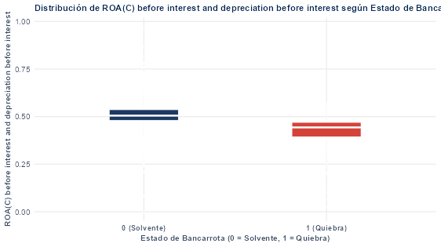

El gráfico compara la distribución de ROA(C) before interest and depreciation before interest entre empresas solventes (0) y en quiebra (1). Se observa que el 50% de las empresas en quiebra se ubica en niveles inferiores de ROA(C) before interest and depreciation before interest (mediana cercana a 44.31%) en comparación con el grupo solvente (mediana cercana a 50.49%). El rango central de los datos (IQR) muestra la dispersión interna de cada segmento, evidenciándose la presencia de valores atípicos (*outliers*) más allá de los bigotes. En resumen, los valores más bajos de ROA(C) before interest and depreciation before interest tienden a concentrarse en las empresas con riesgo de quiebra.

**ROA(A) before interest and % after tax**

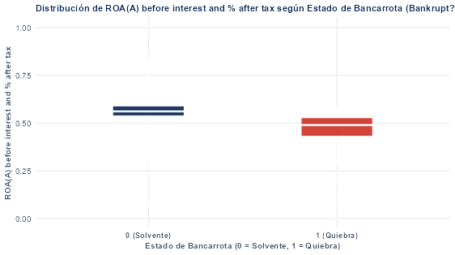

El gráfico compara la distribución de ROA(A) before interest and % after tax entre empresas solventes (0) y en quiebra (1). Se observa que el 50% de las empresas en quiebra se ubica en niveles inferiores de ROA(A) before interest and % after tax (mediana cercana a 49.01%) en comparación con el grupo solvente (mediana cercana a 56.18%). El rango central de los datos (IQR) muestra la dispersión interna de cada segmento, evidenciándose la presencia de valores atípicos (*outliers*) más allá de los bigotes. En resumen, los valores más bajos de ROA(A) before interest and % after tax tienden a concentrarse en las empresas con riesgo de quiebra.

**ROA(B) before interest and depreciation after tax**

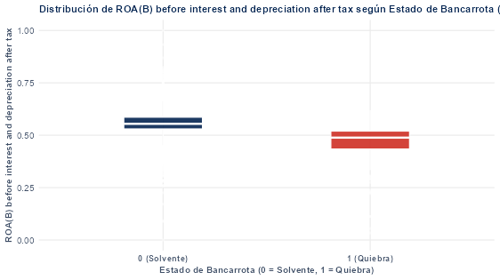

El gráfico compara la distribución de ROA(B) before interest and depreciation after tax entre empresas solventes (0) y en quiebra (1). Se observa que el 50% de las empresas en quiebra se ubica en niveles inferiores de ROA(B) before interest and depreciation after tax (mediana cercana a 48.85%) en comparación con el grupo solvente (mediana cercana a 55.44%). El rango central de los datos (IQR) muestra la dispersión interna de cada segmento, evidenciándose la presencia de valores atípicos (*outliers*) más allá de los bigotes. En resumen, los valores más bajos de ROA(B) before interest and depreciation after tax tienden a concentrarse en las empresas con riesgo de quiebra.

**Operating Gross Margin**

[figure not shown]

El gráfico compara la distribución de Operating Gross Margin entre empresas solventes (0) y en quiebra (1). Se observa medianas visualmente alineadas y un solapamiento alto en sus rangos intercuartílicos. El rango central de los datos (IQR) muestra la dispersión interna de cada segmento, evidenciándose la presencia de valores atípicos (*outliers*) más allá de los bigotes. En resumen, la variable Operating Gross Margin muestra un comportamiento similar entre ambos grupos sin una separación clara a simple vista.

**Realized Sales Gross Margin**

[figure not shown]

El gráfico compara la distribución de Realized Sales Gross Margin entre empresas solventes (0) y en quiebra (1). Se observa medianas visualmente alineadas y un solapamiento alto en sus rangos intercuartílicos. El rango central de los datos (IQR) muestra la dispersión interna de cada segmento, evidenciándose la presencia de valores atípicos (*outliers*) más allá de los bigotes. En resumen, la variable Realized Sales Gross Margin muestra un comportamiento similar entre ambos grupos sin una separación clara a simple vista.

**Operating Profit Rate**

[figure not shown]

El gráfico compara la distribución de Operating Profit Rate entre empresas solventes (0) y en quiebra (1). Se observa medianas visualmente alineadas y un solapamiento alto en sus rangos intercuartílicos. El rango central de los datos (IQR) muestra la dispersión interna de cada segmento, evidenciándose la presencia de valores atípicos (*outliers*) más allá de los bigotes. En resumen, la variable Operating Profit Rate muestra un comportamiento similar entre ambos grupos sin una separación clara a simple vista.

**Pre-tax net Interest Rate**

[figure not shown]

El gráfico compara la distribución de Pre-tax net Interest Rate entre empresas solventes (0) y en quiebra (1). Se observa medianas visualmente alineadas y un solapamiento alto en sus rangos intercuartílicos. El rango central de los datos (IQR) muestra la dispersión interna de cada segmento, evidenciándose la presencia de valores atípicos (*outliers*) más allá de los bigotes. En resumen, la variable Pre-tax net Interest Rate muestra un comportamiento similar entre ambos grupos sin una separación clara a simple vista.

**After-tax net Interest Rate**

[figure not shown]

El gráfico compara la distribución de After-tax net Interest Rate entre empresas solventes (0) y en quiebra (1). Se observa medianas visualmente alineadas y un solapamiento alto en sus rangos intercuartílicos. El rango central de los datos (IQR) muestra la dispersión interna de cada segmento, evidenciándose la presencia de valores atípicos (*outliers*) más allá de los bigotes. En resumen, la variable After-tax net Interest Rate muestra un comportamiento similar entre ambos grupos sin una separación clara a simple vista.

**Non-industry income and expenditure/revenue**

[figure not shown]

El gráfico compara la distribución de Non-industry income and expenditure/revenue entre empresas solventes (0) y en quiebra (1). Se observa medianas visualmente alineadas y un solapamiento alto en sus rangos intercuartílicos. El rango central de los datos (IQR) muestra la dispersión interna de cada segmento, evidenciándose la presencia de valores atípicos (*outliers*) más allá de los bigotes. En resumen, la variable Non-industry income and expenditure/revenue muestra un comportamiento similar entre ambos grupos sin una separación clara a simple vista.

**Continuous interest rate (after tax)**

[figure not shown]

El gráfico compara la distribución de Continuous interest rate (after tax) entre empresas solventes (0) y en quiebra (1). Se observa medianas visualmente alineadas y un solapamiento alto en sus rangos intercuartílicos. El rango central de los datos (IQR) muestra la dispersión interna de cada segmento, evidenciándose la presencia de valores atípicos (*outliers*) más allá de los bigotes. En resumen, la variable Continuous interest rate (after tax) muestra un comportamiento similar entre ambos grupos sin una separación clara a simple vista.

**Operating Expense Rate**

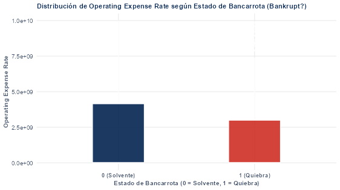

El gráfico compara la distribución de Operating Expense Rate entre empresas solventes (0) y en quiebra (1). Se observa medianas visualmente alineadas y un solapamiento alto en sus rangos intercuartílicos. El rango central de los datos (IQR) muestra la dispersión interna de cada segmento, evidenciándose la presencia de valores atípicos (*outliers*) más allá de los bigotes. En resumen, la variable Operating Expense Rate muestra un comportamiento similar entre ambos grupos sin una separación clara a simple vista.

**Research and development expense rate**

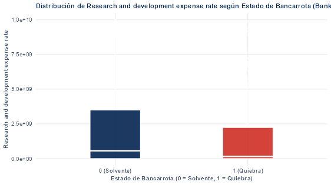

El gráfico compara la distribución de Research and development expense rate entre empresas solventes (0) y en quiebra (1). Se observa que el 50% de las empresas en quiebra se ubica en niveles inferiores de Research and development expense rate (mediana cercana a 15300000000.00%) en comparación con el grupo solvente (mediana cercana a 56000000000.00%). El rango central de los datos (IQR) muestra la dispersión interna de cada segmento, evidenciándose la presencia de valores atípicos (*outliers*) más allá de los bigotes. En resumen, los valores más bajos de Research and development expense rate tienden a concentrarse en las empresas con riesgo de quiebra.

**Cash flow rate**

[figure not shown]

El gráfico compara la distribución de Cash flow rate entre empresas solventes (0) y en quiebra (1). Se observa medianas visualmente alineadas y un solapamiento alto en sus rangos intercuartílicos. El rango central de los datos (IQR) muestra la dispersión interna de cada segmento, evidenciándose la presencia de valores atípicos (*outliers*) más allá de los bigotes. En resumen, la variable Cash flow rate muestra un comportamiento similar entre ambos grupos sin una separación clara a simple vista.

**Interest-bearing debt interest rate**

[figure not shown]

El gráfico compara la distribución de Interest-bearing debt interest rate entre empresas solventes (0) y en quiebra (1). Se observa medianas visualmente alineadas y un solapamiento alto en sus rangos intercuartílicos. El rango central de los datos (IQR) muestra la dispersión interna de cada segmento, evidenciándose la presencia de valores atípicos (*outliers*) más allá de los bigotes. En resumen, la variable Interest-bearing debt interest rate muestra un comportamiento similar entre ambos grupos sin una separación clara a simple vista.

**Tax rate (A)**

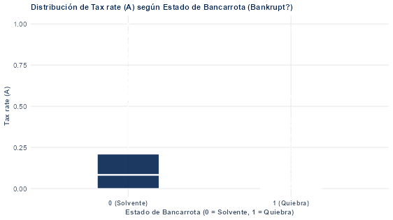

El gráfico compara la distribución de Tax rate (A) entre empresas solventes (0) y en quiebra (1). Se observa que el 50% de las empresas en quiebra se ubica en niveles inferiores de Tax rate (A) (mediana cercana a 0.00%) en comparación con el grupo solvente (mediana cercana a 8.32%). El rango central de los datos (IQR) muestra la dispersión interna de cada segmento, evidenciándose la presencia de valores atípicos (*outliers*) más allá de los bigotes. En resumen, los valores más bajos de Tax rate (A) tienden a concentrarse en las empresas con riesgo de quiebra.

**Net Value Per Share (B)**

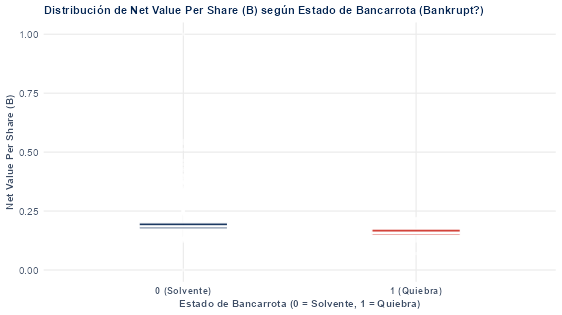

El gráfico compara la distribución de Net Value Per Share (B) entre empresas solventes (0) y en quiebra (1). Se observa que el 50% de las empresas en quiebra se ubica en niveles inferiores de Net Value Per Share (B) (mediana cercana a 0.1579 Yuan ¥/acción) en comparación con el grupo solvente (mediana cercana a 0.1849 Yuan ¥/acción). El rango central de los datos (IQR) muestra la dispersión interna de cada segmento, evidenciándose la presencia de valores atípicos (*outliers*) más allá de los bigotes. En resumen, los valores más bajos de Net Value Per Share (B) tienden a concentrarse en las empresas con riesgo de quiebra.

**Net Value Per Share (A)**

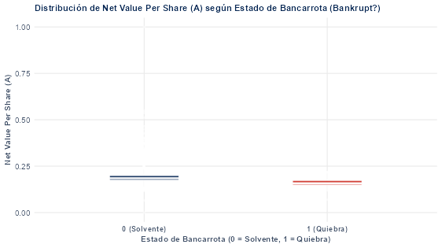

El gráfico compara la distribución de Net Value Per Share (A) entre empresas solventes (0) y en quiebra (1). Se observa que el 50% de las empresas en quiebra se ubica en niveles inferiores de Net Value Per Share (A) (mediana cercana a 0.1579 Yuan ¥/acción) en comparación con el grupo solvente (mediana cercana a 0.1850 Yuan ¥/acción). El rango central de los datos (IQR) muestra la dispersión interna de cada segmento, evidenciándose la presencia de valores atípicos (*outliers*) más allá de los bigotes. En resumen, los valores más bajos de Net Value Per Share (A) tienden a concentrarse en las empresas con riesgo de quiebra.

**Net Value Per Share (C)**

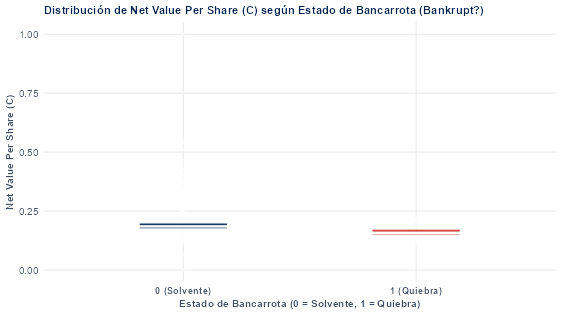

El gráfico compara la distribución de Net Value Per Share (C) entre empresas solventes (0) y en quiebra (1). Se observa que el 50% de las empresas en quiebra se ubica en niveles inferiores de Net Value Per Share (C) (mediana cercana a 0.1579 Yuan ¥/acción) en comparación con el grupo solvente (mediana cercana a 0.1850 Yuan ¥/acción). El rango central de los datos (IQR) muestra la dispersión interna de cada segmento, evidenciándose la presencia de valores atípicos (*outliers*) más allá de los bigotes. En resumen, los valores más bajos de Net Value Per Share (C) tienden a concentrarse en las empresas con riesgo de quiebra.

**Persistent EPS in the Last Four Seasons**

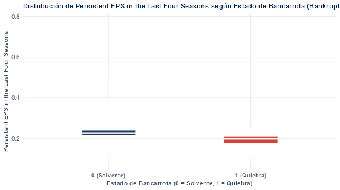

El gráfico compara la distribución de Persistent EPS in the Last Four Seasons entre empresas solventes (0) y en quiebra (1). Se observa que el 50% de las empresas en quiebra se ubica en niveles inferiores de Persistent EPS in the Last Four Seasons (mediana cercana a 0.1969 Yuan ¥/acción) en comparación con el grupo solvente (mediana cercana a 0.2253 Yuan ¥/acción). El rango central de los datos (IQR) muestra la dispersión interna de cada segmento, evidenciándose la presencia de valores atípicos (*outliers*) más allá de los bigotes. En resumen, los valores más bajos de Persistent EPS in the Last Four Seasons tienden a concentrarse en las empresas con riesgo de quiebra.

**Cash Flow Per Share**

[figure not shown]

El gráfico compara la distribución de Cash Flow Per Share entre empresas solventes (0) y en quiebra (1). Se observa medianas visualmente alineadas y un solapamiento alto en sus rangos intercuartílicos. El rango central de los datos (IQR) muestra la dispersión interna de cada segmento, evidenciándose la presencia de valores atípicos (*outliers*) más allá de los bigotes. En resumen, la variable Cash Flow Per Share muestra un comportamiento similar entre ambos grupos sin una separación clara a simple vista.

**Revenue Per Share (Yuan ¥)**

[figure not shown]

**Operating Profit Per Share (Yuan ¥)**

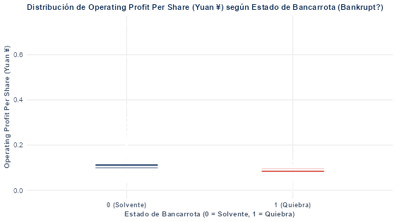

El gráfico compara la distribución de Operating Profit Per Share (Yuan ¥) entre empresas solventes (0) y en quiebra (1). Se observa que el 50% de las empresas en quiebra se ubica en niveles inferiores de Operating Profit Per Share (Yuan ¥) (mediana cercana a 0.0903 Yuan ¥/acción) en comparación con el grupo solvente (mediana cercana a 0.1048 Yuan ¥/acción). El rango central de los datos (IQR) muestra la dispersión interna de cada segmento, evidenciándose la presencia de valores atípicos (*outliers*) más allá de los bigotes. En resumen, los valores más bajos de Operating Profit Per Share (Yuan ¥) tienden a concentrarse en las empresas con riesgo de quiebra.

**Per Share Net profit before tax (Yuan ¥)**

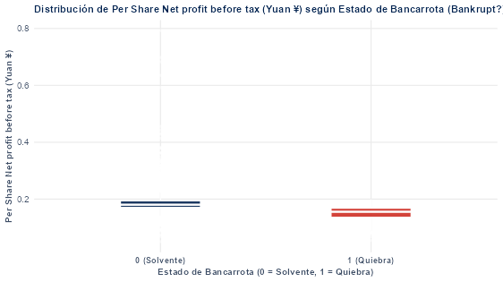

El gráfico compara la distribución de Per Share Net profit before tax (Yuan ¥) entre empresas solventes (0) y en quiebra (1). Se observa que el 50% de las empresas en quiebra se ubica en niveles inferiores de Per Share Net profit before tax (Yuan ¥) (mediana cercana a 0.1555 Yuan ¥/acción) en comparación con el grupo solvente (mediana cercana a 0.1804 Yuan ¥/acción). El rango central de los datos (IQR) muestra la dispersión interna de cada segmento, evidenciándose la presencia de valores atípicos (*outliers*) más allá de los bigotes. En resumen, los valores más bajos de Per Share Net profit before tax (Yuan ¥) tienden a concentrarse en las empresas con riesgo de quiebra.